# Investigating Violent Crimes: a Human Issue

```r
library(ggplot2)
library(glmnet)
crime <- read.csv("crime_re1.csv")
crime$Violent.crime <- as.numeric(crime$Violent.crime)
crime <- na.omit(crime)
crime$Violent.crime <- (100000*crime$Violent.crime/crime$POPESTIMATE) #adjust crime quantity by population into crime per 100,000 people
# summary(crime)
# names(crime)
```

# 1 Abstract

Violent crimes are a profound human issue that affects millions of Americans daily. Many intertwined factors create a butterfly effect, rippling across racial, economic, and social boundaries and contributing to staggering crime rates. This study collects data on various factors that plausibly affect the violent crime rate and aims to shed light on the significant influences. Through the Least Absolute Shrinkage and Selection Operator (LASSO) to filter significant variables and using backward selection to eliminate insignificant factors, we present three models that started with different variable inclusions. By utilizing testing data to calculate the error of each model, the final LASSO model reveals that the percentage of people owning houses, the black/African American and mixed race population rate, seemingly positively correlate with violent crime rates, although causation cannot be proven with statistical tools. Meanwhile, the percentage of people with college degrees or higher and high-speed Internet access appears to decrease violent crime rates, yet evidence of causation remains lacking.

# 2 Purpose of the Study

In the past decades, policy makers and ordinary citizens have debated over the cause of crimes. However, many of the discussions served a dual purpose of attacking opposite political party. With the data and analysis of this research, one purpose of our study is to eliminate any party’s prejudice and statistically show significant factors that influence the violent crime rate in America.

Considering the future of children, families and millions of ordinary Americans, such data and research is necessary to provide actual progress towards understanding how to create a more safe and inclusive environment for any American.

This work also attempts to inform policy makers of possible factors influencing violent crime rates, although the limitation of the scale of this research might not be sufficient to influence institutional decision making. In this account, another significant purpose of this study is also to enlighten or inspire more statisticians to dive into similar investigations, whether through collecting data or analyzing on a grander scale.

# 3 Information about the Data

Our data is sourced by county for the 50 states of America not including territories. We combined 60 data sets in order to create our master file. Data mainly came from official US government pages such as the Census Bureau, FBI, or independent sources like the Pew Research Center. Since all the desired data is hard to obtain for the same year, we gathered data from different years to form our data.

In meeting NA values, we directly omit them since rows with NA values consists of around 13% of the data, which is not that significant. This is a reasonable approach considering difficulties in tracking down individual county’s data within limited time.

[output not shown]

The sources of data are listed here as well as the github link for all the files.

[Kaggle](https://www.kaggle.com/datasets/leoliu1415/number-of-violent-crimes-by-county)

[Github folder](https://github.com/Jacob-RC/WhartonDataScience2023)

[Violent Crime](https://ucr.fbi.gov/crime-in-the-u.s/2016/crime-in-the-u.s.-2016/tables/table-8/table-8.xls/view)

[Population](https://www.census.gov/data/tables/time-series/demo/popest/2020s-counties-total.html)

[Police Force Numbers](https://cde.ucr.cjis.gov/LATEST/webapp/#/pages/downloads)

[Race Breakdown](https://www.kaggle.com/datasets/mikejohnsonjr/us-counties-diversity-index)

[Party Affiliation](https://www.pewresearch.org/religion/religious-landscape-study/compare/party-affiliation/by/state/)

[Internet Access](https://www.fcc.gov/form-477-county-data-internet-access-services)

[Annual Income](https://apps.bea.gov/regional/downloadzip.cfm)

[Age Range](https://www.census.gov/data/tables/time-series/demo/popest/2020s-counties-detail.html)

# 4 Exploratory Data Analysis

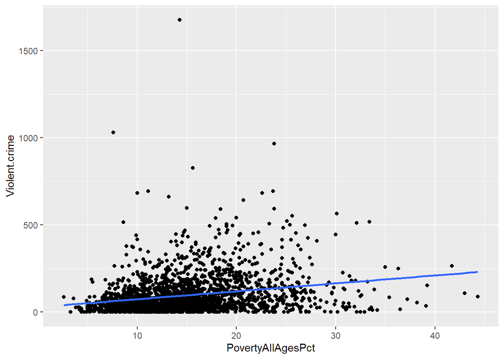

```r
# #Violent crime with politic parties
# ggplot(crime, aes(x=Republican,y=Violent.crime)) +
#     geom_point() +
#     geom_smooth(method=lm, se=FALSE)
#
# ggplot(crime, aes(x=Democrat,y=Violent.crime)) +
#     geom_point() +
#     geom_smooth(method=lm, se=FALSE)


#Violent crime with income, poverty
ggplot(crime, aes(x=PovertyAllAgesPct,y=Violent.crime)) +
    geom_point() +
    geom_smooth(method=lm, se=FALSE)
```

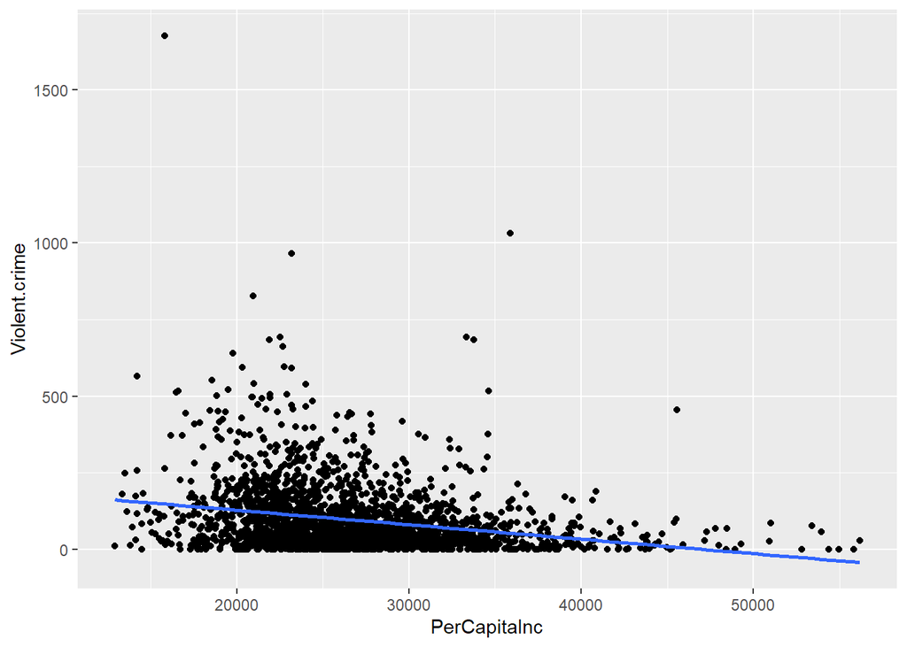

```r
ggplot(crime, aes(x=PerCapitaInc,y=Violent.crime)) +
    geom_point() +
    geom_smooth(method=lm, se=FALSE)
```

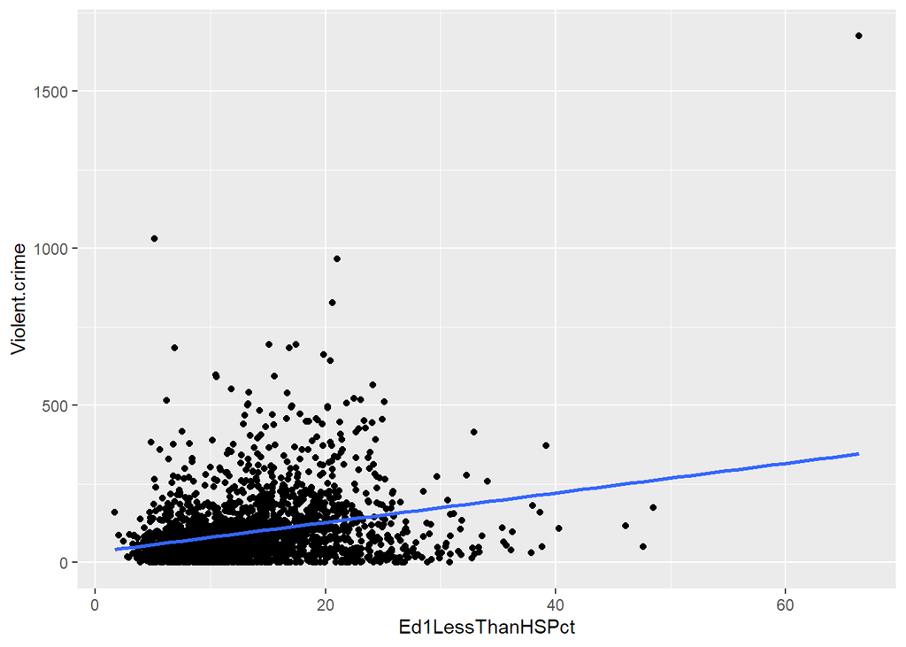

```r
#Violent with Education
ggplot(crime, aes(x=Ed1LessThanHSPct,y=Violent.crime)) +
    geom_point() +
    geom_smooth(method=lm, se=FALSE)
```

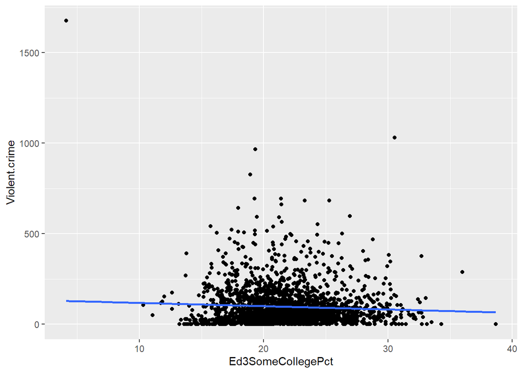

```r
ggplot(crime, aes(x=Ed3SomeCollegePct,y=Violent.crime)) +
    geom_point() +
    geom_smooth(method=lm, se=FALSE)
```

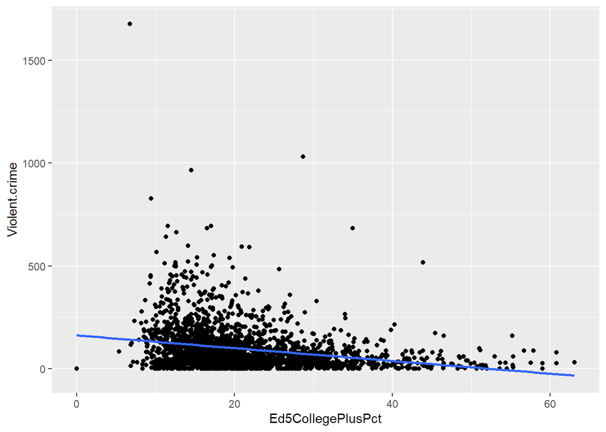

```r
ggplot(crime, aes(x=Ed5CollegePlusPct,y=Violent.crime)) +
    geom_point() +
    geom_smooth(method=lm, se=FALSE)
```

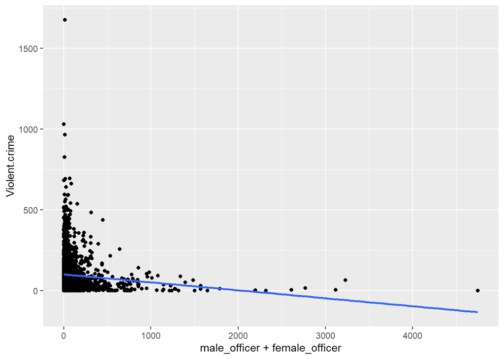

```r
#Violent with police officers
ggplot(crime, aes(x=male_officer+female_officer,y=Violent.crime)) +
    geom_point() +
    geom_smooth(method=lm, se=FALSE)
```

```r
# ggplot(crime, aes(x=Asian.alone..percent..2013,y=Violent.crime)) +
#     geom_point() +
#     geom_smooth(method=lm, se=FALSE)
#
# #
# ggplot(crime, aes(x=Black.or.African.American.alone..percent..2013,y=Violent.crime)) +
#     geom_point() +
#     geom_smooth(method=lm, se=FALSE)
# #
# ggplot(crime, aes(x=American.Indian.and.Alaska.Native.alone..percent..2013,y=Violent.crime)) +
#     geom_point() +
#     geom_smooth(method=lm, se=FALSE)
```

```r
fit_race <- lm(Violent.crime~Black.or.African.American.alone..percent..2013+
                 American.Indian.and.Alaska.Native.alone..percent..2013+
                 Asian.alone..percent..2013+
                 Native.Hawaiian.and.Other.Pacific.Islander.alone..percent.+
                 Two.or.More.Races..percent..2013+
                 Hispanic.or.Latino..percent..2013+
                 White.alone..not.Hispanic.or.Latino..percent..2013,data=crime)
summary(fit_race)
```

```
##
## Call:
## lm(formula = Violent.crime ~ Black.or.African.American.alone..percent..2013 +
##     American.Indian.and.Alaska.Native.alone..percent..2013 +
##     Asian.alone..percent..2013 + Native.Hawaiian.and.Other.Pacific.Islander.alone..percent. +
##     Two.or.More.Races..percent..2013 + Hispanic.or.Latino..percent..2013 +
##     White.alone..not.Hispanic.or.Latino..percent..2013, data = crime)
##
## Residuals:
##     Min      1Q  Median      3Q     Max
## -222.92  -60.08  -28.52   28.99 1543.01
##
## Coefficients:
##                                                            Estimate Std. Error
## (Intercept)                                                1342.709    448.940
## Black.or.African.American.alone..percent..2013              -10.270      4.449
## American.Indian.and.Alaska.Native.alone..percent..2013      -11.172      4.362
## Asian.alone..percent..2013                                  -23.858      4.414
## Native.Hawaiian.and.Other.Pacific.Islander.alone..percent.  -11.985     17.123
## Two.or.More.Races..percent..2013                            -10.292      4.591
## Hispanic.or.Latino..percent..2013                           -11.713      4.307
## White.alone..not.Hispanic.or.Latino..percent..2013          -12.553      4.491
##                                                            t value Pr(>|t|)
## (Intercept)                                                  2.991  0.00281 **
## Black.or.African.American.alone..percent..2013              -2.309  0.02106 *
## American.Indian.and.Alaska.Native.alone..percent..2013      -2.561  0.01050 *
## Asian.alone..percent..2013                                  -5.405 7.19e-08 ***
## Native.Hawaiian.and.Other.Pacific.Islander.alone..percent.  -0.700  0.48403
## Two.or.More.Races..percent..2013                            -2.242  0.02509 *
## Hispanic.or.Latino..percent..2013                           -2.719  0.00659 **
## White.alone..not.Hispanic.or.Latino..percent..2013          -2.795  0.00523 **
## ---
## Signif. codes:  0 '***' 0.001 '**' 0.01 '*' 0.05 '.' 0.1 ' ' 1
##
## Residual standard error: 105.6 on 2184 degrees of freedom
## Multiple R-squared:  0.09185,    Adjusted R-squared:  0.08894
## F-statistic: 31.55 on 7 and 2184 DF,  p-value: < 2.2e-16
```

```r
fit_age <- lm(Violent.crime~AGE04_TOT+AGE59_TOT+AGE1014_TOT+AGE1519_TOT+AGE2024_TOT+
              AGE2529_TOT+AGE3034_TOT+AGE3539_TOT+AGE4044_TOT+
              AGE4549_TOT+AGE5054_TOT+AGE5559_TOT+AGE6064_TOT+
              AGE6569_TOT+AGE7074_TOT+AGE7579_TOT+AGE8084_TOT+AGE85PLUS_TOT
                ,data=crime)
summary(fit_age)
```

```
##
## Call:
## lm(formula = Violent.crime ~ AGE04_TOT + AGE59_TOT + AGE1014_TOT +
##     AGE1519_TOT + AGE2024_TOT + AGE2529_TOT + AGE3034_TOT + AGE3539_TOT +
##     AGE4044_TOT + AGE4549_TOT + AGE5054_TOT + AGE5559_TOT + AGE6064_TOT +
##     AGE6569_TOT + AGE7074_TOT + AGE7579_TOT + AGE8084_TOT + AGE85PLUS_TOT,
##     data = crime)
##
## Residuals:
##     Min      1Q  Median      3Q     Max
## -182.35  -64.38  -28.08   28.73 1571.90
##
## Coefficients:
##                 Estimate Std. Error t value Pr(>|t|)
## (Intercept)   104.364673   2.774777  37.612  < 2e-16 ***
## AGE04_TOT      -0.011074   0.007047  -1.571  0.11623
## AGE59_TOT       0.013872   0.013181   1.052  0.29273
## AGE1014_TOT    -0.004304   0.010853  -0.397  0.69170
## AGE1519_TOT    -0.003164   0.004791  -0.660  0.50905
## AGE2024_TOT    -0.002482   0.002393  -1.037  0.29983
## AGE2529_TOT     0.005896   0.004661   1.265  0.20603
## AGE3034_TOT     0.005684   0.006362   0.893  0.37171
## AGE3539_TOT    -0.009048   0.009756  -0.927  0.35381
## AGE4044_TOT    -0.002038   0.012637  -0.161  0.87188
## AGE4549_TOT     0.011349   0.012463   0.911  0.36258
## AGE5054_TOT    -0.017672   0.013147  -1.344  0.17901
## AGE5559_TOT     0.027379   0.013851   1.977  0.04819 *
## AGE6064_TOT    -0.025677   0.015120  -1.698  0.08962 .
## AGE6569_TOT     0.015432   0.016124   0.957  0.33864
## AGE7074_TOT    -0.010910   0.017189  -0.635  0.52570
## AGE7579_TOT     0.003880   0.017762   0.218  0.82709
## AGE8084_TOT     0.038861   0.025247   1.539  0.12389
## AGE85PLUS_TOT  -0.032812   0.010722  -3.060  0.00224 **
## ---
## Signif. codes:  0 '***' 0.001 '**' 0.01 '*' 0.05 '.' 0.1 ' ' 1
##
## Residual standard error: 108.7 on 2173 degrees of freedom
## Multiple R-squared:  0.04281,    Adjusted R-squared:  0.03488
## F-statistic: 5.399 on 18 and 2173 DF,  p-value: 1.519e-12
```

```r
fit_male <- lm(Violent.crime~AGE04_MALE+AGE59_MALE+AGE1014_MALE+AGE1519_MALE+AGE2024_MALE+
              AGE2529_MALE+AGE3034_MALE+AGE3539_MALE+AGE4044_MALE+
              AGE4549_MALE+AGE5054_MALE+AGE5559_MALE+AGE6064_MALE+
              AGE6569_MALE+AGE7074_MALE+AGE7579_MALE+AGE8084_MALE+AGE85PLUS_MALE
                ,data=crime)
summary(fit_male)
```

```
##
## Call:
## lm(formula = Violent.crime ~ AGE04_MALE + AGE59_MALE + AGE1014_MALE +
##     AGE1519_MALE + AGE2024_MALE + AGE2529_MALE + AGE3034_MALE +
##     AGE3539_MALE + AGE4044_MALE + AGE4549_MALE + AGE5054_MALE +
##     AGE5559_MALE + AGE6064_MALE + AGE6569_MALE + AGE7074_MALE +
##     AGE7579_MALE + AGE8084_MALE + AGE85PLUS_MALE, data = crime)
##
## Residuals:
##     Min      1Q  Median      3Q     Max
## -152.10  -64.84  -29.01   29.17 1571.10
##
## Coefficients:
##                  Estimate Std. Error t value Pr(>|t|)
## (Intercept)    104.973465   2.800552  37.483   <2e-16 ***
## AGE04_MALE      -0.017171   0.012245  -1.402   0.1610
## AGE59_MALE       0.012540   0.022516   0.557   0.5776
## AGE1014_MALE     0.005975   0.019379   0.308   0.7579
## AGE1519_MALE    -0.004747   0.010102  -0.470   0.6384
## AGE2024_MALE    -0.004701   0.004580  -1.026   0.3048
## AGE2529_MALE     0.005152   0.008866   0.581   0.5613
## AGE3034_MALE     0.017684   0.012063   1.466   0.1428
## AGE3539_MALE    -0.014088   0.017786  -0.792   0.4284
## AGE4044_MALE    -0.020850   0.021908  -0.952   0.3414
## AGE4549_MALE     0.038765   0.019849   1.953   0.0509 .
## AGE5054_MALE    -0.042501   0.019832  -2.143   0.0322 *
## AGE5559_MALE     0.042298   0.022944   1.843   0.0654 .
## AGE6064_MALE    -0.031419   0.024607  -1.277   0.2018
## AGE6569_MALE     0.020395   0.025541   0.799   0.4247
## AGE7074_MALE    -0.037552   0.028266  -1.329   0.1841
## AGE7579_MALE     0.072149   0.031858   2.265   0.0236 *
## AGE8084_MALE    -0.021626   0.051810  -0.417   0.6764
## AGE85PLUS_MALE  -0.043755   0.026857  -1.629   0.1034
## ---
## Signif. codes:  0 '***' 0.001 '**' 0.01 '*' 0.05 '.' 0.1 ' ' 1
##
## Residual standard error: 108.8 on 2173 degrees of freedom
## Multiple R-squared:  0.0414, Adjusted R-squared:  0.03346
## F-statistic: 5.214 on 18 and 2173 DF,  p-value: 5.752e-12
```

```r
fit_fem <- lm(Violent.crime~AGE04_FEM+AGE59_FEM+AGE1014_FEM+AGE1519_FEM+AGE2024_FEM+
              AGE2529_FEM+AGE3034_FEM+AGE3539_FEM+AGE4044_FEM+
              AGE4549_FEM+AGE5054_FEM+AGE5559_FEM+AGE6064_FEM+
              AGE6569_FEM+AGE7074_FEM+AGE7579_FEM+AGE8084_FEM+AGE85PLUS_FEM
                ,data=crime)
summary(fit_fem)
```

```
##
## Call:
## lm(formula = Violent.crime ~ AGE04_FEM + AGE59_FEM + AGE1014_FEM +
##     AGE1519_FEM + AGE2024_FEM + AGE2529_FEM + AGE3034_FEM + AGE3539_FEM +
##     AGE4044_FEM + AGE4549_FEM + AGE5054_FEM + AGE5559_FEM + AGE6064_FEM +
##     AGE6569_FEM + AGE7074_FEM + AGE7579_FEM + AGE8084_FEM + AGE85PLUS_FEM,
##     data = crime)
##
## Residuals:
##     Min      1Q  Median      3Q     Max
## -213.84  -64.37  -28.13   29.84 1571.30
##
## Coefficients:
##                 Estimate Std. Error t value Pr(>|t|)
## (Intercept)    1.051e+02  2.749e+00  38.219  < 2e-16 ***
## AGE04_FEM     -2.121e-02  1.400e-02  -1.515   0.1298
## AGE59_FEM      3.350e-02  2.400e-02   1.396   0.1628
## AGE1014_FEM   -1.789e-02  1.887e-02  -0.948   0.3432
## AGE1519_FEM   -6.672e-03  7.790e-03  -0.856   0.3918
## AGE2024_FEM   -4.689e-03  4.278e-03  -1.096   0.2732
## AGE2529_FEM    1.592e-02  8.338e-03   1.910   0.0563 .
## AGE3034_FEM    3.183e-03  1.144e-02   0.278   0.7808
## AGE3539_FEM   -1.249e-02  1.665e-02  -0.750   0.4534
## AGE4044_FEM   -9.048e-05  2.132e-02  -0.004   0.9966
## AGE4549_FEM    6.029e-03  2.270e-02   0.266   0.7905
## AGE5054_FEM   -1.124e-02  2.484e-02  -0.452   0.6510
## AGE5559_FEM    3.994e-02  2.309e-02   1.729   0.0839 .
## AGE6064_FEM   -4.439e-02  2.531e-02  -1.754   0.0796 .
## AGE6569_FEM    1.507e-02  2.772e-02   0.544   0.5867
## AGE7074_FEM    5.544e-03  2.970e-02   0.187   0.8519
## AGE7579_FEM   -2.304e-02  2.981e-02  -0.773   0.4395
## AGE8084_FEM    1.028e-01  3.579e-02   2.874   0.0041 **
## AGE85PLUS_FEM -6.313e-02  1.481e-02  -4.262 2.11e-05 ***
## ---
## Signif. codes:  0 '***' 0.001 '**' 0.01 '*' 0.05 '.' 0.1 ' ' 1
##
## Residual standard error: 108.6 on 2173 degrees of freedom
## Multiple R-squared:  0.04518,    Adjusted R-squared:  0.03727
## F-statistic: 5.712 on 18 and 2173 DF,  p-value: 1.565e-13
```

```r
fit_edu <- lm(Violent.crime~Ed1LessThanHSPct+Ed3SomeCollegePct+Ed5CollegePlusPct
                ,data=crime)
summary(fit_edu)
```

```
##
## Call:
## lm(formula = Violent.crime ~ Ed1LessThanHSPct + Ed3SomeCollegePct +
##     Ed5CollegePlusPct, data = crime)
##
## Residuals:
##     Min      1Q  Median      3Q     Max
## -171.26  -59.33  -23.59   29.08 1381.25
##
## Coefficients:
##                   Estimate Std. Error t value Pr(>|t|)
## (Intercept)        71.0801    23.3755   3.041  0.00239 **
## Ed1LessThanHSPct    3.4984     0.5036   6.946 4.93e-12 ***
## Ed3SomeCollegePct   0.5234     0.6916   0.757  0.44925
## Ed5CollegePlusPct  -1.5644     0.3389  -4.616 4.14e-06 ***
## ---
## Signif. codes:  0 '***' 0.001 '**' 0.01 '*' 0.05 '.' 0.1 ' ' 1
##
## Residual standard error: 106 on 2188 degrees of freedom
## Multiple R-squared:  0.08361,    Adjusted R-squared:  0.08235
## F-statistic: 66.54 on 3 and 2188 DF,  p-value: < 2.2e-16
```

```r
fit_police <- lm(Violent.crime~male_officer+female_officer
                ,data=crime)
summary(fit_police)
```

```
##
## Call:
## lm(formula = Violent.crime ~ male_officer + female_officer, data = crime)
##
## Residuals:
##     Min      1Q  Median      3Q     Max
## -142.12  -66.86  -29.92   30.73 1573.50
##
## Coefficients:
##                 Estimate Std. Error t value Pr(>|t|)
## (Intercept)    104.16173    2.62037  39.751  < 2e-16 ***
## male_officer    -0.14052    0.02743  -5.123 3.27e-07 ***
## female_officer   0.38364    0.12274   3.126   0.0018 **
## ---
## Signif. codes:  0 '***' 0.001 '**' 0.01 '*' 0.05 '.' 0.1 ' ' 1
##
## Residual standard error: 109.7 on 2189 degrees of freedom
## Multiple R-squared:  0.0181, Adjusted R-squared:  0.0172
## F-statistic: 20.18 on 2 and 2189 DF,  p-value: 2.076e-09
```

```r
fit_income <- lm(Violent.crime~OwnHomePct+NumUnemployed2019+Housing_Units+PerCapitaInc
                ,data=crime)
summary(fit_income)
```

```
##
## Call:
## lm(formula = Violent.crime ~ OwnHomePct + NumUnemployed2019 +
##     Housing_Units + PerCapitaInc, data = crime)
##
## Residuals:
##     Min      1Q  Median      3Q     Max
## -159.41  -61.78  -24.88   27.79 1572.37
##
## Coefficients:
##                     Estimate Std. Error t value Pr(>|t|)
## (Intercept)        1.381e+02  2.429e+01   5.687 1.47e-08 ***
## OwnHomePct         1.234e+00  3.340e-01   3.694 0.000226 ***
## NumUnemployed2019 -9.199e-03  3.929e-03  -2.341 0.019311 *
## Housing_Units      3.703e-04  1.841e-04   2.011 0.044436 *
## PerCapitaInc      -4.831e-03  4.259e-04 -11.345  < 2e-16 ***
## ---
## Signif. codes:  0 '***' 0.001 '**' 0.01 '*' 0.05 '.' 0.1 ' ' 1
##
## Residual standard error: 106.6 on 2187 degrees of freedom
## Multiple R-squared:  0.07366,    Adjusted R-squared:  0.07196
## F-statistic: 43.47 on 4 and 2187 DF,  p-value: < 2.2e-16
```

# 5 Analysis with LASSO

## 5.1 LASSO Everything

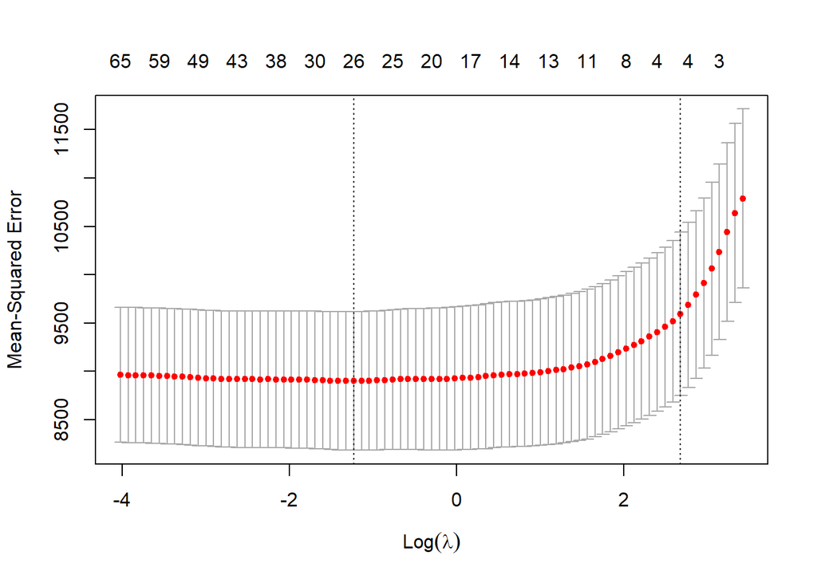

```r
set.seed(527)
# Separate testing data with training data with 80% being training
sample <- sample(c(TRUE,FALSE),nrow(crime),replace=TRUE,prob=c(0.8,0.2))
crime1 <- crime[sample,]
test <- crime[!sample,]
crime <- crime1

y_lasso <- crime$Violent.crime # extract Y
x_lasso <- model.matrix(Violent.crime~., data=crime)[, -1]
fit_lasso <- cv.glmnet(x = x_lasso,y=y_lasso,data=crime,alpha=1,nfolds = 10)
plot(fit_lasso)
```

```r
fit_lasso$lambda.min
```

```
## [1] 0.292687
```

```r
fit_lasso_model <- glmnet(x = x_lasso,y=y_lasso,data=crime,alpha=1,lambda=2.016)
sig_var <- coef(fit_lasso_model)
as.data.frame(sig_var[which(sig_var !=0),])
```

```
##                                                        sig_var[which(sig_var != 0), ]
## (Intercept)                                                              7.451249e+01
## MEDIAN_AGE_MALE                                                          3.682421e-01
## PerCapitaInc                                                            -2.667126e-04
## PovertyAllAgesPct                                                        4.352798e-01
## Ed1LessThanHSPct                                                         1.074562e+00
## Ed5CollegePlusPct                                                       -2.702516e-01
## OwnHomePct                                                               1.458358e+00
## NumUnemployed2019                                                       -5.989559e-04
## Tier_2                                                                  -6.939812e+00
## Tier_3                                                                  -1.370243e+01
## Democrat                                                                -1.804076e+02
## Black.or.African.American.alone..percent..2013                           1.969030e+00
## American.Indian.and.Alaska.Native.alone..percent..2013                   7.519355e-01
## Two.or.More.Races..percent..2013                                         2.486252e+00
## Hispanic.or.Latino..percent..2013                                       -6.922249e-02
```

The remaining variables are the ones that are significant after applying LASSO.

```r
# seed was set but still outputs random result.... But key point is just taking non zero coefficient variables. The variables used here was from one random output lambda that we couldn't recreate.
fit_lm <- lm(Violent.crime~AGE85PLUS_FEM+Ed3SomeCollegePct+
               Ed5CollegePlusPct+OwnHomePct+NumUnemployed2019+Tier_2+Tier_3+Tier_4+
               Democrat+Black.or.African.American.alone..percent..2013+
               Black.or.African.American.alone..percent..2013+
               Native.Hawaiian.and.Other.Pacific.Islander.alone..percent.+
               Two.or.More.Races..percent..2013+
               White.alone..not.Hispanic.or.Latino..percent..2013
               ,data=crime)
summary(fit_lm)
```

```
##
## Call:
## lm(formula = Violent.crime ~ AGE85PLUS_FEM + Ed3SomeCollegePct +
##     Ed5CollegePlusPct + OwnHomePct + NumUnemployed2019 + Tier_2 +
##     Tier_3 + Tier_4 + Democrat + Black.or.African.American.alone..percent..2013 +
##     Black.or.African.American.alone..percent..2013 + Native.Hawaiian.and.Other.Pacific.Islander.alone..percent. +
##     Two.or.More.Races..percent..2013 + White.alone..not.Hispanic.or.Latino..percent..2013,
##     data = crime)
##
## Residuals:
##     Min      1Q  Median      3Q     Max
## -214.08  -53.53  -19.09   27.57  767.01
##
## Coefficients:
##                                                              Estimate
## (Intercept)                                                 1.551e+02
## AGE85PLUS_FEM                                              -2.505e-05
## Ed3SomeCollegePct                                          -3.450e-01
## Ed5CollegePlusPct                                          -1.161e+00
## OwnHomePct                                                  1.721e+00
## NumUnemployed2019                                          -1.076e-03
## Tier_2                                                     -1.079e+01
## Tier_3                                                     -1.758e+01
## Tier_4                                                      7.263e+00
## Democrat                                                   -2.329e+02
## Black.or.African.American.alone..percent..2013              2.100e+00
## Native.Hawaiian.and.Other.Pacific.Islander.alone..percent. -1.714e+01
## Two.or.More.Races..percent..2013                            6.939e+00
## White.alone..not.Hispanic.or.Latino..percent..2013         -2.568e-01
##                                                            Std. Error t value
## (Intercept)                                                 3.981e+01   3.897
## AGE85PLUS_FEM                                               3.764e-03  -0.007
## Ed3SomeCollegePct                                           6.595e-01  -0.523
## Ed5CollegePlusPct                                           3.539e-01  -3.282
## OwnHomePct                                                  3.739e-01   4.604
## NumUnemployed2019                                           2.401e-03  -0.448
## Tier_2                                                      5.019e+00  -2.150
## Tier_3                                                      4.830e+00  -3.640
## Tier_4                                                      4.600e+00   1.579
## Democrat                                                    4.920e+01  -4.733
```

[output cut: 10 more lines]

```
## NumUnemployed2019                                          0.653982
## Tier_2                                                     0.031685 *
## Tier_3                                                     0.000281 ***
## Tier_4                                                     0.114559
## Democrat                                                   2.39e-06 ***
## Black.or.African.American.alone..percent..2013              < 2e-16 ***
## Native.Hawaiian.and.Other.Pacific.Islander.alone..percent. 0.335894
## Two.or.More.Races..percent..2013                           0.002694 **
## White.alone..not.Hispanic.or.Latino..percent..2013         0.142927
## ---
## Signif. codes:  0 '***' 0.001 '**' 0.01 '*' 0.05 '.' 0.1 ' ' 1
##
## Residual standard error: 94.08 on 1724 degrees of freedom
## Multiple R-squared:  0.1864, Adjusted R-squared:  0.1802
## F-statistic: 30.38 on 13 and 1724 DF,  p-value: < 2.2e-16
```

From the results of relaxed LASSO, not all variable have low enough p-value to be significant, therefore backward selection is applied to further deduct dimension and leave more significant variables. The first variable to be eliminated is AGE85PLUS_FEM.

```r
fit_lm_back1 <- lm(Violent.crime~Ed3SomeCollegePct+
               Ed5CollegePlusPct+OwnHomePct+NumUnemployed2019+Tier_2+Tier_3+Tier_4+
               Democrat+Black.or.African.American.alone..percent..2013+
               Black.or.African.American.alone..percent..2013+
               Native.Hawaiian.and.Other.Pacific.Islander.alone..percent.+
               Two.or.More.Races..percent..2013+
               White.alone..not.Hispanic.or.Latino..percent..2013
               ,data=crime)
summary(fit_lm_back1)
```

```
##
## Call:
## lm(formula = Violent.crime ~ Ed3SomeCollegePct + Ed5CollegePlusPct +
##     OwnHomePct + NumUnemployed2019 + Tier_2 + Tier_3 + Tier_4 +
##     Democrat + Black.or.African.American.alone..percent..2013 +
##     Black.or.African.American.alone..percent..2013 + Native.Hawaiian.and.Other.Pacific.Islander.alone..percent. +
##     Two.or.More.Races..percent..2013 + White.alone..not.Hispanic.or.Latino..percent..2013,
##     data = crime)
##
## Residuals:
##     Min      1Q  Median      3Q     Max
## -214.08  -53.53  -19.09   27.57  767.01
##
## Coefficients:
##                                                              Estimate
## (Intercept)                                                 1.551e+02
## Ed3SomeCollegePct                                          -3.447e-01
## Ed5CollegePlusPct                                          -1.162e+00
## OwnHomePct                                                  1.721e+00
## NumUnemployed2019                                          -1.092e-03
## Tier_2                                                     -1.079e+01
## Tier_3                                                     -1.758e+01
## Tier_4                                                      7.261e+00
## Democrat                                                   -2.329e+02
## Black.or.African.American.alone..percent..2013              2.100e+00
## Native.Hawaiian.and.Other.Pacific.Islander.alone..percent. -1.714e+01
## Two.or.More.Races..percent..2013                            6.939e+00
## White.alone..not.Hispanic.or.Latino..percent..2013         -2.570e-01
##                                                            Std. Error t value
## (Intercept)                                                 3.967e+01   3.911
## Ed3SomeCollegePct                                           6.578e-01  -0.524
## Ed5CollegePlusPct                                           3.513e-01  -3.308
## OwnHomePct                                                  3.737e-01   4.606
## NumUnemployed2019                                           6.651e-04  -1.641
## Tier_2                                                      5.017e+00  -2.151
## Tier_3                                                      4.827e+00  -3.642
## Tier_4                                                      4.590e+00   1.582
## Democrat                                                    4.911e+01  -4.742
## Black.or.African.American.alone..percent..2013              2.325e-01   9.032
## Native.Hawaiian.and.Other.Pacific.Islander.alone..percent.  1.780e+01  -0.963
## Two.or.More.Races..percent..2013                            2.308e+00   3.007
## White.alone..not.Hispanic.or.Latino..percent..2013          1.736e-01  -1.481
##                                                            Pr(>|t|)
## (Intercept)                                                9.56e-05 ***
## Ed3SomeCollegePct                                          0.600296
## Ed5CollegePlusPct                                          0.000961 ***
## OwnHomePct                                                 4.41e-06 ***
## NumUnemployed2019                                          0.100876
## Tier_2                                                     0.031629 *
## Tier_3                                                     0.000279 ***
## Tier_4                                                     0.113841
## Democrat                                                   2.29e-06 ***
## Black.or.African.American.alone..percent..2013              < 2e-16 ***
## Native.Hawaiian.and.Other.Pacific.Islander.alone..percent. 0.335760
## Two.or.More.Races..percent..2013                           0.002680 **
## White.alone..not.Hispanic.or.Latino..percent..2013         0.138882
## ---
## Signif. codes:  0 '***' 0.001 '**' 0.01 '*' 0.05 '.' 0.1 ' ' 1
##
## Residual standard error: 94.05 on 1725 degrees of freedom
## Multiple R-squared:  0.1864, Adjusted R-squared:  0.1807
## F-statistic: 32.93 on 12 and 1725 DF,  p-value: < 2.2e-16
```

```r
fit_lm_back2 <- lm(Violent.crime~Ed3SomeCollegePct+
               Ed5CollegePlusPct+OwnHomePct+NumUnemployed2019+Tier_3+Tier_4+
               Democrat+Black.or.African.American.alone..percent..2013+
               Black.or.African.American.alone..percent..2013+
               Native.Hawaiian.and.Other.Pacific.Islander.alone..percent.+
               Two.or.More.Races..percent..2013+
               White.alone..not.Hispanic.or.Latino..percent..2013
               ,data=crime)
summary(fit_lm_back2)
```

```
##
## Call:
## lm(formula = Violent.crime ~ Ed3SomeCollegePct + Ed5CollegePlusPct +
##     OwnHomePct + NumUnemployed2019 + Tier_3 + Tier_4 + Democrat +
##     Black.or.African.American.alone..percent..2013 + Black.or.African.American.alone..percent..2013 +
##     Native.Hawaiian.and.Other.Pacific.Islander.alone..percent. +
##     Two.or.More.Races..percent..2013 + White.alone..not.Hispanic.or.Latino..percent..2013,
##     data = crime)
##
## Residuals:
##     Min      1Q  Median      3Q     Max
## -216.68  -52.98  -19.29   27.78  761.50
##
## Coefficients:
##                                                              Estimate
## (Intercept)                                                 1.363e+02
## Ed3SomeCollegePct                                          -4.129e-01
## Ed5CollegePlusPct                                          -1.282e+00
## OwnHomePct                                                  1.754e+00
## NumUnemployed2019                                          -1.191e-03
## Tier_3                                                     -2.279e+01
## Tier_4                                                      5.073e+00
## Democrat                                                   -2.247e+02
## Black.or.African.American.alone..percent..2013              2.169e+00
## Native.Hawaiian.and.Other.Pacific.Islander.alone..percent. -1.922e+01
## Two.or.More.Races..percent..2013                            7.211e+00
## White.alone..not.Hispanic.or.Latino..percent..2013         -2.448e-01
##                                                            Std. Error t value
## (Intercept)                                                 3.873e+01   3.519
## Ed3SomeCollegePct                                           6.577e-01  -0.628
## Ed5CollegePlusPct                                           3.471e-01  -3.695
## OwnHomePct                                                  3.738e-01   4.693
## NumUnemployed2019                                           6.642e-04  -1.793
## Tier_3                                                      4.179e+00  -5.454
## Tier_4                                                      4.480e+00   1.132
## Democrat                                                    4.902e+01  -4.584
## Black.or.African.American.alone..percent..2013              2.305e-01   9.412
## Native.Hawaiian.and.Other.Pacific.Islander.alone..percent.  1.779e+01  -1.080
## Two.or.More.Races..percent..2013                            2.307e+00   3.126
## White.alone..not.Hispanic.or.Latino..percent..2013          1.736e-01  -1.410
##                                                            Pr(>|t|)
## (Intercept)                                                0.000445 ***
## Ed3SomeCollegePct                                          0.530205
## Ed5CollegePlusPct                                          0.000227 ***
## OwnHomePct                                                 2.91e-06 ***
## NumUnemployed2019                                          0.073074 .
## Tier_3                                                     5.65e-08 ***
## Tier_4                                                     0.257640
## Democrat                                                   4.89e-06 ***
## Black.or.African.American.alone..percent..2013              < 2e-16 ***
## Native.Hawaiian.and.Other.Pacific.Islander.alone..percent. 0.280324
## Two.or.More.Races..percent..2013                           0.001802 **
## White.alone..not.Hispanic.or.Latino..percent..2013         0.158867
## ---
## Signif. codes:  0 '***' 0.001 '**' 0.01 '*' 0.05 '.' 0.1 ' ' 1
##
## Residual standard error: 94.15 on 1726 degrees of freedom
## Multiple R-squared:  0.1842, Adjusted R-squared:  0.179
## F-statistic: 35.43 on 11 and 1726 DF,  p-value: < 2.2e-16
```

Next insignificant variable is NumUnemployed2019.

```r
fit_lm_back3 <- lm(Violent.crime~Ed3SomeCollegePct+
               Ed5CollegePlusPct+OwnHomePct+Tier_3+Tier_4+
               Democrat+Black.or.African.American.alone..percent..2013+
               Black.or.African.American.alone..percent..2013+
               Native.Hawaiian.and.Other.Pacific.Islander.alone..percent.+
               Two.or.More.Races..percent..2013+
               White.alone..not.Hispanic.or.Latino..percent..2013
               ,data=crime)
summary(fit_lm_back3)
```

```
##
## Call:
## lm(formula = Violent.crime ~ Ed3SomeCollegePct + Ed5CollegePlusPct +
##     OwnHomePct + Tier_3 + Tier_4 + Democrat + Black.or.African.American.alone..percent..2013 +
##     Black.or.African.American.alone..percent..2013 + Native.Hawaiian.and.Other.Pacific.Islander.alone..percent. +
##     Two.or.More.Races..percent..2013 + White.alone..not.Hispanic.or.Latino..percent..2013,
##     data = crime)
##
## Residuals:
##     Min      1Q  Median      3Q     Max
## -216.09  -53.48  -18.81   27.81  763.19
##
## Coefficients:
##                                                             Estimate Std. Error
## (Intercept)                                                 135.0797    38.7512
## Ed3SomeCollegePct                                            -0.3911     0.6580
## Ed5CollegePlusPct                                            -1.3658     0.3442
## OwnHomePct                                                    1.8034     0.3731
## Tier_3                                                      -23.1471     4.1773
## Tier_4                                                        3.9276     4.4374
## Democrat                                                   -233.8230    48.7838
## Black.or.African.American.alone..percent..2013                2.1763     0.2306
## Native.Hawaiian.and.Other.Pacific.Islander.alone..percent.  -19.7207    17.8039
## Two.or.More.Races..percent..2013                              7.1277     2.3078
## White.alone..not.Hispanic.or.Latino..percent..2013           -0.1949     0.1715
##                                                            t value Pr(>|t|)
## (Intercept)                                                  3.486 0.000503 ***
## Ed3SomeCollegePct                                           -0.594 0.552303
## Ed5CollegePlusPct                                           -3.968 7.54e-05 ***
## OwnHomePct                                                   4.834 1.46e-06 ***
## Tier_3                                                      -5.541 3.47e-08 ***
## Tier_4                                                       0.885 0.376226
## Democrat                                                    -4.793 1.78e-06 ***
## Black.or.African.American.alone..percent..2013               9.437  < 2e-16 ***
## Native.Hawaiian.and.Other.Pacific.Islander.alone..percent.  -1.108 0.268164
## Two.or.More.Races..percent..2013                             3.089 0.002043 **
## White.alone..not.Hispanic.or.Latino..percent..2013          -1.136 0.255997
## ---
## Signif. codes:  0 '***' 0.001 '**' 0.01 '*' 0.05 '.' 0.1 ' ' 1
##
## Residual standard error: 94.21 on 1727 degrees of freedom
## Multiple R-squared:  0.1827, Adjusted R-squared:  0.1779
## F-statistic:  38.6 on 10 and 1727 DF,  p-value: < 2.2e-16
```

```r
fit_lm_back4 <- lm(Violent.crime~Ed3SomeCollegePct+
               Ed5CollegePlusPct+OwnHomePct+Tier_3+Tier_4+
               Democrat+Black.or.African.American.alone..percent..2013+
               Black.or.African.American.alone..percent..2013+
               Native.Hawaiian.and.Other.Pacific.Islander.alone..percent.+
               Two.or.More.Races..percent..2013
               ,data=crime)
summary(fit_lm_back4)
```

```
##
## Call:
## lm(formula = Violent.crime ~ Ed3SomeCollegePct + Ed5CollegePlusPct +
##     OwnHomePct + Tier_3 + Tier_4 + Democrat + Black.or.African.American.alone..percent..2013 +
##     Black.or.African.American.alone..percent..2013 + Native.Hawaiian.and.Other.Pacific.Islander.alone..percent. +
##     Two.or.More.Races..percent..2013, data = crime)
##
## Residuals:
##     Min      1Q  Median      3Q     Max
## -213.95  -53.56  -18.91   28.29  763.73
##
## Coefficients:
##                                                             Estimate Std. Error
## (Intercept)                                                 124.7247    37.6676
## Ed3SomeCollegePct                                            -0.3852     0.6580
## Ed5CollegePlusPct                                            -1.3890     0.3436
## OwnHomePct                                                    1.6959     0.3609
## Tier_3                                                      -22.9948     4.1755
## Tier_4                                                        3.5932     4.4280
## Democrat                                                   -231.3013    48.7374
## Black.or.African.American.alone..percent..2013                2.3275     0.1884
## Native.Hawaiian.and.Other.Pacific.Islander.alone..percent.  -17.6603    17.7128
## Two.or.More.Races..percent..2013                              7.5679     2.2752
##                                                            t value Pr(>|t|)
## (Intercept)                                                  3.311 0.000948 ***
## Ed3SomeCollegePct                                           -0.585 0.558322
## Ed5CollegePlusPct                                           -4.042 5.53e-05 ***
## OwnHomePct                                                   4.699 2.82e-06 ***
## Tier_3                                                      -5.507 4.20e-08 ***
## Tier_4                                                       0.811 0.417212
## Democrat                                                    -4.746 2.25e-06 ***
## Black.or.African.American.alone..percent..2013              12.356  < 2e-16 ***
## Native.Hawaiian.and.Other.Pacific.Islander.alone..percent.  -0.997 0.318887
## Two.or.More.Races..percent..2013                             3.326 0.000899 ***
## ---
## Signif. codes:  0 '***' 0.001 '**' 0.01 '*' 0.05 '.' 0.1 ' ' 1
##
## Residual standard error: 94.22 on 1728 degrees of freedom
## Multiple R-squared:  0.1821, Adjusted R-squared:  0.1778
## F-statistic: 42.74 on 9 and 1728 DF,  p-value: < 2.2e-16
```

```r
fit_lm_back5 <- lm(Violent.crime~
               Ed5CollegePlusPct+OwnHomePct+Tier_3+Tier_4+
               Democrat+Black.or.African.American.alone..percent..2013+
               Black.or.African.American.alone..percent..2013+
               Native.Hawaiian.and.Other.Pacific.Islander.alone..percent.+
               Two.or.More.Races..percent..2013
               ,data=crime)
summary(fit_lm_back5)
```

```
##
## Call:
## lm(formula = Violent.crime ~ Ed5CollegePlusPct + OwnHomePct +
##     Tier_3 + Tier_4 + Democrat + Black.or.African.American.alone..percent..2013 +
##     Black.or.African.American.alone..percent..2013 + Native.Hawaiian.and.Other.Pacific.Islander.alone..percent. +
##     Two.or.More.Races..percent..2013, data = crime)
##
## Residuals:
##     Min      1Q  Median      3Q     Max
## -213.35  -53.28  -19.28   28.55  763.72
##
## Coefficients:
##                                                             Estimate Std. Error
## (Intercept)                                                 115.2538    34.0104
## Ed5CollegePlusPct                                            -1.3916     0.3435
## OwnHomePct                                                    1.6841     0.3603
## Tier_3                                                      -23.0178     4.1745
## Tier_4                                                        3.7088     4.4228
## Democrat                                                   -225.7323    47.7910
## Black.or.African.American.alone..percent..2013                2.3419     0.1867
## Native.Hawaiian.and.Other.Pacific.Islander.alone..percent.  -18.8186    17.5987
## Two.or.More.Races..percent..2013                              7.2929     2.2258
##                                                            t value Pr(>|t|)
## (Intercept)                                                  3.389 0.000718 ***
## Ed5CollegePlusPct                                           -4.051 5.33e-05 ***
## OwnHomePct                                                   4.674 3.18e-06 ***
## Tier_3                                                      -5.514 4.04e-08 ***
## Tier_4                                                       0.839 0.401824
## Democrat                                                    -4.723 2.51e-06 ***
## Black.or.African.American.alone..percent..2013              12.543  < 2e-16 ***
## Native.Hawaiian.and.Other.Pacific.Islander.alone..percent.  -1.069 0.285075
## Two.or.More.Races..percent..2013                             3.277 0.001071 **
## ---
## Signif. codes:  0 '***' 0.001 '**' 0.01 '*' 0.05 '.' 0.1 ' ' 1
##
## Residual standard error: 94.2 on 1729 degrees of freedom
## Multiple R-squared:  0.1819, Adjusted R-squared:  0.1781
## F-statistic: 48.06 on 8 and 1729 DF,  p-value: < 2.2e-16
```

```r
fit_lm_back6 <- lm(Violent.crime~
               Ed5CollegePlusPct+OwnHomePct+Tier_3+Tier_4+
               Democrat+Black.or.African.American.alone..percent..2013+
               Black.or.African.American.alone..percent..2013+
               Two.or.More.Races..percent..2013
               ,data=crime)
summary(fit_lm_back6)
```

```
##
## Call:
## lm(formula = Violent.crime ~ Ed5CollegePlusPct + OwnHomePct +
##     Tier_3 + Tier_4 + Democrat + Black.or.African.American.alone..percent..2013 +
##     Black.or.African.American.alone..percent..2013 + Two.or.More.Races..percent..2013,
##     data = crime)
##
## Residuals:
##     Min      1Q  Median      3Q     Max
## -214.92  -53.45  -19.51   28.27  762.22
##
## Coefficients:
##                                                 Estimate Std. Error t value
## (Intercept)                                     108.5092    33.4218   3.247
## Ed5CollegePlusPct                                -1.3891     0.3435  -4.044
## OwnHomePct                                        1.7619     0.3529   4.993
## Tier_3                                          -23.2928     4.1667  -5.590
## Tier_4                                            3.6152     4.4221   0.818
## Democrat                                       -222.6181    47.7041  -4.667
## Black.or.African.American.alone..percent..2013    2.3488     0.1866  12.587
## Two.or.More.Races..percent..2013                  6.8216     2.1818   3.127
##                                                Pr(>|t|)
## (Intercept)                                     0.00119 **
## Ed5CollegePlusPct                              5.50e-05 ***
## OwnHomePct                                     6.54e-07 ***
## Tier_3                                         2.63e-08 ***
## Tier_4                                          0.41374
## Democrat                                       3.30e-06 ***
## Black.or.African.American.alone..percent..2013  < 2e-16 ***
## Two.or.More.Races..percent..2013                0.00180 **
## ---
## Signif. codes:  0 '***' 0.001 '**' 0.01 '*' 0.05 '.' 0.1 ' ' 1
##
## Residual standard error: 94.2 on 1730 degrees of freedom
## Multiple R-squared:  0.1814, Adjusted R-squared:  0.1781
## F-statistic: 54.75 on 7 and 1730 DF,  p-value: < 2.2e-16
```

```r
fit_lm_back7 <- lm(Violent.crime~
               Ed5CollegePlusPct+OwnHomePct+Tier_4+
               Democrat+Black.or.African.American.alone..percent..2013+
               Black.or.African.American.alone..percent..2013+
               Two.or.More.Races..percent..2013
               ,data=crime)
summary(fit_lm_back7)
```

```
##
## Call:
## lm(formula = Violent.crime ~ Ed5CollegePlusPct + OwnHomePct +
##     Tier_4 + Democrat + Black.or.African.American.alone..percent..2013 +
##     Black.or.African.American.alone..percent..2013 + Two.or.More.Races..percent..2013,
##     data = crime)
##
## Residuals:
##     Min      1Q  Median      3Q     Max
## -199.17  -55.23  -20.85   30.37  773.56
##
## Coefficients:
##                                                 Estimate Std. Error t value
## (Intercept)                                      75.2809    33.1751   2.269
## Ed5CollegePlusPct                                -1.8341     0.3371  -5.441
## OwnHomePct                                        1.9257     0.3547   5.429
## Tier_4                                          -10.5844     3.6513  -2.899
## Democrat                                       -237.0954    48.0482  -4.935
## Black.or.African.American.alone..percent..2013    2.4243     0.1877  12.913
## Two.or.More.Races..percent..2013                  7.5301     2.1970   3.427
##                                                Pr(>|t|)
## (Intercept)                                    0.023379 *
## Ed5CollegePlusPct                              6.06e-08 ***
## OwnHomePct                                     6.46e-08 ***
## Tier_4                                         0.003793 **
## Democrat                                       8.81e-07 ***
## Black.or.African.American.alone..percent..2013  < 2e-16 ***
## Two.or.More.Races..percent..2013               0.000624 ***
## ---
## Signif. codes:  0 '***' 0.001 '**' 0.01 '*' 0.05 '.' 0.1 ' ' 1
##
## Residual standard error: 95.02 on 1731 degrees of freedom
## Multiple R-squared:  0.1666, Adjusted R-squared:  0.1637
## F-statistic: 57.66 on 6 and 1731 DF,  p-value: < 2.2e-16
```

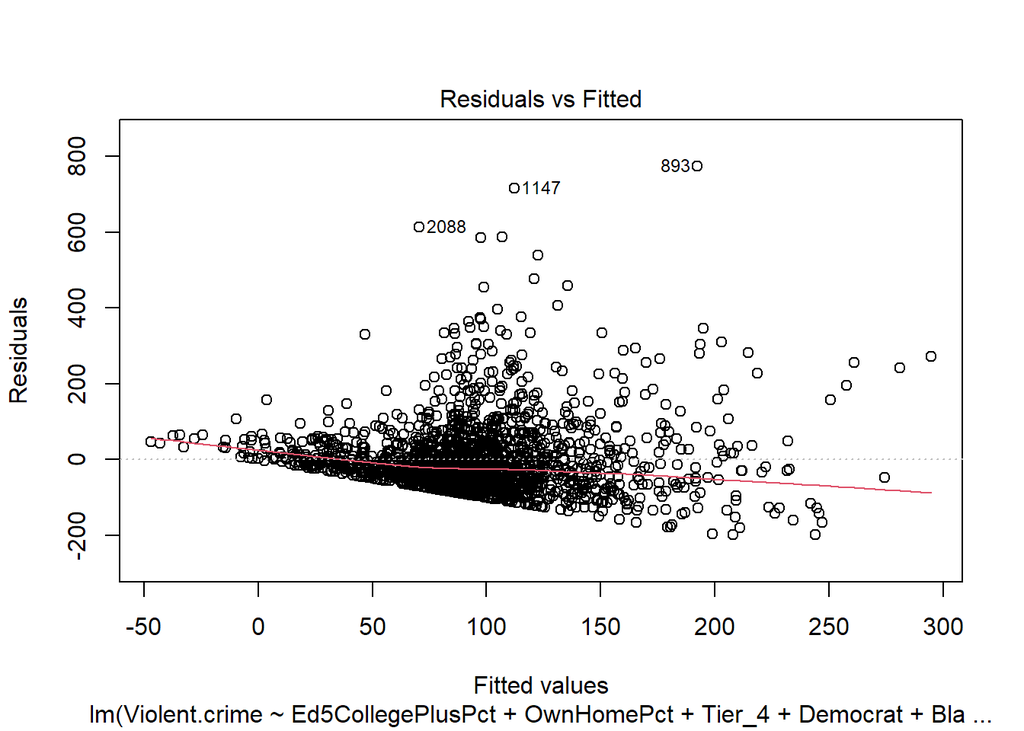

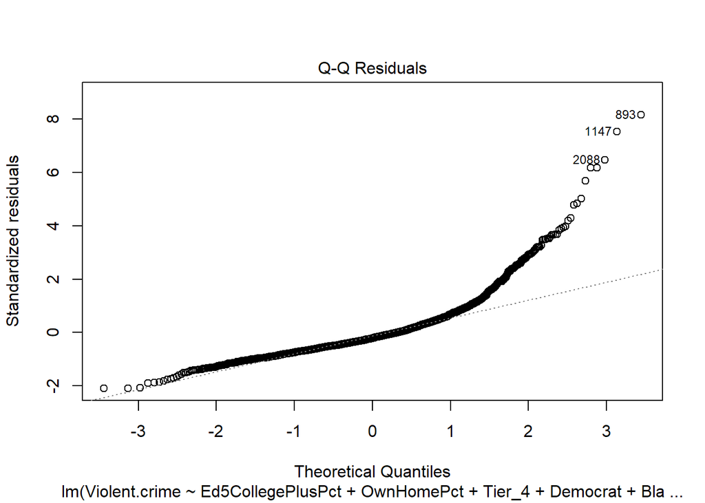

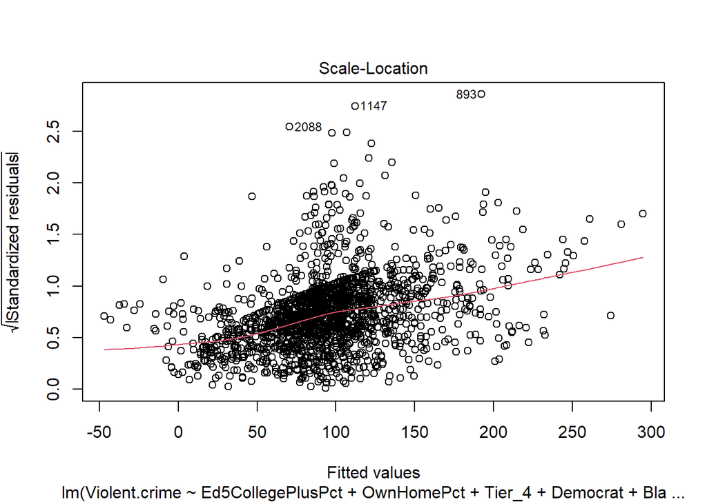

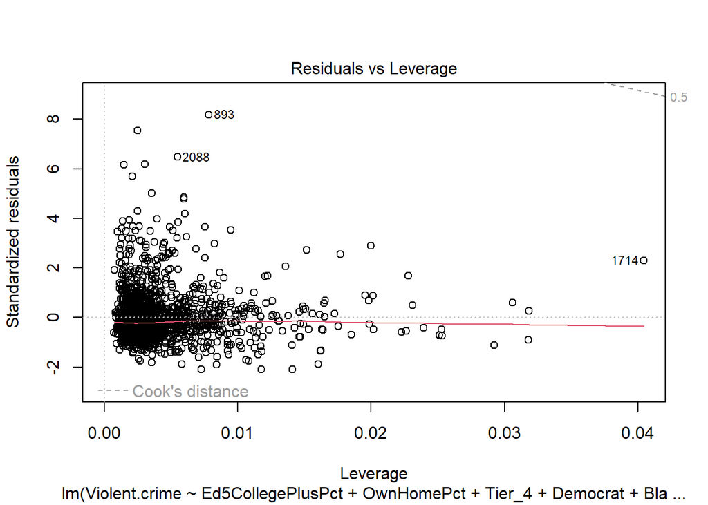

```r
plot(fit_lm_back7)
```

## 5.2 LASSO without Internet

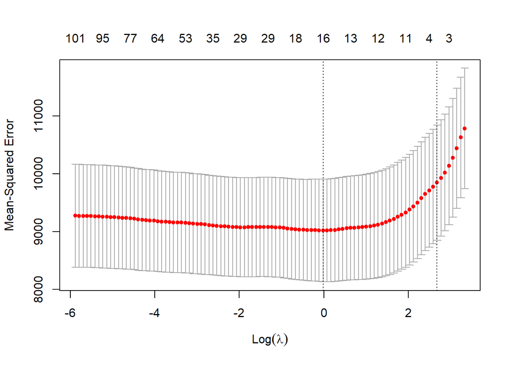

```r
set.seed(527)
x_lasso_no_int <- model.matrix(Violent.crime~.-Tier_1-Tier_2-Tier_3-Tier_4, data=crime)[, -1]
fit_lasso_2 <- cv.glmnet(x = x_lasso_no_int,y=y_lasso,data=crime,alpha=1,nfolds = 10)
plot(fit_lasso_2)
```

```r
#fit_lasso_2$lambda.min=3.66

fit_lasso_model_2 <- glmnet(x = x_lasso_no_int,y=y_lasso,data=crime,alpha=1,lambda=3.66)
sig_var_2 <- coef(fit_lasso_model_2)
as.data.frame(sig_var_2[which(sig_var_2 !=0),])
```

```
##                                                        sig_var_2[which(sig_var_2 != 0), ]
## (Intercept)                                                                  2.559800e+01
## AGE85PLUS_FEM                                                               -7.091179e-05
## MEDIAN_AGE_MALE                                                              1.179477e+00
## PerCapitaInc                                                                -7.445954e-04
## PovertyAllAgesPct                                                            9.656613e-01
## Ed1LessThanHSPct                                                             7.059094e-01
## Ed5CollegePlusPct                                                           -8.641088e-01
## OwnHomePct                                                                   1.309898e+00
## NumUnemployed2019                                                           -7.632469e-04
## Democrat                                                                    -1.857571e+02
## Black.or.African.American.alone..percent..2013                               1.831298e+00
## American.Indian.and.Alaska.Native.alone..percent..2013                       8.147959e-01
## Two.or.More.Races..percent..2013                                             3.718418e-01
```

```r
fit_lm_2 <- lm(Violent.crime~AGE1824_MALE+MEDIAN_AGE_MALE+Ed3SomeCollegePct+
               Ed5CollegePlusPct+OwnHomePct+Democrat+Black.or.African.American.alone..percent..2013+
               Native.Hawaiian.and.Other.Pacific.Islander.alone..percent.+
               Two.or.More.Races..percent..2013+White.alone..not.Hispanic.or.Latino..percent..2013
               ,data=crime)
summary(fit_lm_2)
```

```
##
## Call:
## lm(formula = Violent.crime ~ AGE1824_MALE + MEDIAN_AGE_MALE +
##     Ed3SomeCollegePct + Ed5CollegePlusPct + OwnHomePct + Democrat +
##     Black.or.African.American.alone..percent..2013 + Native.Hawaiian.and.Other.Pacific.Islander.alone..percent. +
##     Two.or.More.Races..percent..2013 + White.alone..not.Hispanic.or.Latino..percent..2013,
##     data = crime)
##
## Residuals:
##     Min      1Q  Median      3Q     Max
## -213.06  -54.22  -21.76   30.65  771.76
##
## Coefficients:
##                                                              Estimate
## (Intercept)                                                 1.004e+02
## AGE1824_MALE                                               -5.415e-04
## MEDIAN_AGE_MALE                                             1.685e+00
## Ed3SomeCollegePct                                          -6.795e-01
## Ed5CollegePlusPct                                          -2.074e+00
## OwnHomePct                                                  1.419e+00
## Democrat                                                   -2.794e+02
## Black.or.African.American.alone..percent..2013              2.110e+00
## Native.Hawaiian.and.Other.Pacific.Islander.alone..percent. -2.367e+01
## Two.or.More.Races..percent..2013                            8.042e+00
## White.alone..not.Hispanic.or.Latino..percent..2013         -4.093e-01
##                                                            Std. Error t value
## (Intercept)                                                 3.876e+01   2.589
## AGE1824_MALE                                                2.644e-04  -2.048
## MEDIAN_AGE_MALE                                             5.840e-01   2.886
## Ed3SomeCollegePct                                           6.693e-01  -1.015
## Ed5CollegePlusPct                                           2.984e-01  -6.951
## OwnHomePct                                                  4.197e-01   3.382
## Democrat                                                    4.837e+01  -5.776
## Black.or.African.American.alone..percent..2013              2.365e-01   8.920
## Native.Hawaiian.and.Other.Pacific.Islander.alone..percent.  1.791e+01  -1.321
## Two.or.More.Races..percent..2013                            2.319e+00   3.468
## White.alone..not.Hispanic.or.Latino..percent..2013          1.828e-01  -2.239
##                                                            Pr(>|t|)
## (Intercept)                                                0.009704 **
## AGE1824_MALE                                               0.040721 *
## MEDIAN_AGE_MALE                                            0.003951 **
## Ed3SomeCollegePct                                          0.310194
## Ed5CollegePlusPct                                          5.13e-12 ***
## OwnHomePct                                                 0.000736 ***
## Democrat                                                   9.04e-09 ***
## Black.or.African.American.alone..percent..2013              < 2e-16 ***
## Native.Hawaiian.and.Other.Pacific.Islander.alone..percent. 0.186574
## Two.or.More.Races..percent..2013                           0.000537 ***
## White.alone..not.Hispanic.or.Latino..percent..2013         0.025282 *
## ---
## Signif. codes:  0 '***' 0.001 '**' 0.01 '*' 0.05 '.' 0.1 ' ' 1
##
## Residual standard error: 94.89 on 1727 degrees of freedom
## Multiple R-squared:  0.1708, Adjusted R-squared:  0.166
## F-statistic: 35.56 on 10 and 1727 DF,  p-value: < 2.2e-16
```

```r
fit_lm_2_back1 <- lm(Violent.crime~AGE1824_MALE+Ed3SomeCollegePct+
               Ed5CollegePlusPct+OwnHomePct+Democrat+Black.or.African.American.alone..percent..2013+
               Native.Hawaiian.and.Other.Pacific.Islander.alone..percent.+
               Two.or.More.Races..percent..2013+White.alone..not.Hispanic.or.Latino..percent..2013
               ,data=crime)
summary(fit_lm_2_back1)
```

```
##
## Call:
## lm(formula = Violent.crime ~ AGE1824_MALE + Ed3SomeCollegePct +
##     Ed5CollegePlusPct + OwnHomePct + Democrat + Black.or.African.American.alone..percent..2013 +
##     Native.Hawaiian.and.Other.Pacific.Islander.alone..percent. +
##     Two.or.More.Races..percent..2013 + White.alone..not.Hispanic.or.Latino..percent..2013,
##     data = crime)
##
## Residuals:
##     Min      1Q  Median      3Q     Max
## -199.25  -55.89  -21.14   31.70  767.44
##
## Coefficients:
##                                                              Estimate
## (Intercept)                                                 1.057e+02
## AGE1824_MALE                                               -5.783e-04
## Ed3SomeCollegePct                                          -4.112e-01
## Ed5CollegePlusPct                                          -2.097e+00
## OwnHomePct                                                  1.964e+00
## Democrat                                                   -2.667e+02
## Black.or.African.American.alone..percent..2013              2.246e+00
## Native.Hawaiian.and.Other.Pacific.Islander.alone..percent. -2.732e+01
## Two.or.More.Races..percent..2013                            8.171e+00
## White.alone..not.Hispanic.or.Latino..percent..2013         -2.526e-01
##                                                            Std. Error t value
## (Intercept)                                                 3.880e+01   2.725
## AGE1824_MALE                                                2.647e-04  -2.185
## Ed3SomeCollegePct                                           6.643e-01  -0.619
## Ed5CollegePlusPct                                           2.990e-01  -7.013
## OwnHomePct                                                  3.757e-01   5.226
## Democrat                                                    4.828e+01  -5.525
## Black.or.African.American.alone..percent..2013              2.322e-01   9.673
## Native.Hawaiian.and.Other.Pacific.Islander.alone..percent.  1.791e+01  -1.525
## Two.or.More.Races..percent..2013                            2.323e+00   3.517
## White.alone..not.Hispanic.or.Latino..percent..2013          1.749e-01  -1.444
##                                                            Pr(>|t|)
## (Intercept)                                                0.006503 **
## AGE1824_MALE                                               0.029026 *
## Ed3SomeCollegePct                                          0.535972
## Ed5CollegePlusPct                                          3.34e-12 ***
## OwnHomePct                                                 1.94e-07 ***
## Democrat                                                   3.80e-08 ***
## Black.or.African.American.alone..percent..2013              < 2e-16 ***
## Native.Hawaiian.and.Other.Pacific.Islander.alone..percent. 0.127328
## Two.or.More.Races..percent..2013                           0.000448 ***
## White.alone..not.Hispanic.or.Latino..percent..2013         0.148974
## ---
## Signif. codes:  0 '***' 0.001 '**' 0.01 '*' 0.05 '.' 0.1 ' ' 1
##
## Residual standard error: 95.1 on 1728 degrees of freedom
## Multiple R-squared:  0.1668, Adjusted R-squared:  0.1624
## F-statistic: 38.43 on 9 and 1728 DF,  p-value: < 2.2e-16
```

```r
fit_lm_2_back2 <- lm(Violent.crime~AGE1824_MALE+Ed3SomeCollegePct+
               Ed5CollegePlusPct+OwnHomePct+Democrat+Black.or.African.American.alone..percent..2013+
               Native.Hawaiian.and.Other.Pacific.Islander.alone..percent.+
               Two.or.More.Races..percent..2013
               ,data=crime)
summary(fit_lm_2_back2)
```

```
##
## Call:
## lm(formula = Violent.crime ~ AGE1824_MALE + Ed3SomeCollegePct +
##     Ed5CollegePlusPct + OwnHomePct + Democrat + Black.or.African.American.alone..percent..2013 +
##     Native.Hawaiian.and.Other.Pacific.Islander.alone..percent. +
##     Two.or.More.Races..percent..2013, data = crime)
##
## Residuals:
##     Min      1Q  Median      3Q     Max
## -196.64  -55.66  -21.12   31.53  767.98
##
## Coefficients:
##                                                              Estimate
## (Intercept)                                                 9.187e+01
## AGE1824_MALE                                               -5.181e-04
## Ed3SomeCollegePct                                          -3.932e-01
## Ed5CollegePlusPct                                          -2.165e+00
## OwnHomePct                                                  1.846e+00
## Democrat                                                   -2.657e+02
## Black.or.African.American.alone..percent..2013              2.439e+00
## Native.Hawaiian.and.Other.Pacific.Islander.alone..percent. -2.496e+01
## Two.or.More.Races..percent..2013                            8.717e+00
##                                                            Std. Error t value
## (Intercept)                                                 3.761e+01   2.443
## AGE1824_MALE                                                2.614e-04  -1.982
## Ed3SomeCollegePct                                           6.644e-01  -0.592
## Ed5CollegePlusPct                                           2.953e-01  -7.333
## OwnHomePct                                                  3.668e-01   5.031
## Democrat                                                    4.828e+01  -5.502
## Black.or.African.American.alone..percent..2013              1.902e-01  12.823
## Native.Hawaiian.and.Other.Pacific.Islander.alone..percent.  1.784e+01  -1.399
## Two.or.More.Races..percent..2013                            2.293e+00   3.801
##                                                            Pr(>|t|)
## (Intercept)                                                0.014674 *
## AGE1824_MALE                                               0.047668 *
## Ed3SomeCollegePct                                          0.554034
## Ed5CollegePlusPct                                          3.45e-13 ***
## OwnHomePct                                                 5.39e-07 ***
## Democrat                                                   4.31e-08 ***
## Black.or.African.American.alone..percent..2013              < 2e-16 ***
## Native.Hawaiian.and.Other.Pacific.Islander.alone..percent. 0.161892
## Two.or.More.Races..percent..2013                           0.000149 ***
## ---
## Signif. codes:  0 '***' 0.001 '**' 0.01 '*' 0.05 '.' 0.1 ' ' 1
##
## Residual standard error: 95.13 on 1729 degrees of freedom
## Multiple R-squared:  0.1658, Adjusted R-squared:  0.1619
## F-statistic: 42.94 on 8 and 1729 DF,  p-value: < 2.2e-16
```

```r
fit_lm_2_back3 <- lm(Violent.crime~Ed3SomeCollegePct+
               Ed5CollegePlusPct+OwnHomePct+Democrat+Black.or.African.American.alone..percent..2013+
               Native.Hawaiian.and.Other.Pacific.Islander.alone..percent.+
               Two.or.More.Races..percent..2013
               ,data=crime)
summary(fit_lm_2_back3)
```

```
##
## Call:
## lm(formula = Violent.crime ~ Ed3SomeCollegePct + Ed5CollegePlusPct +
##     OwnHomePct + Democrat + Black.or.African.American.alone..percent..2013 +
##     Native.Hawaiian.and.Other.Pacific.Islander.alone..percent. +
##     Two.or.More.Races..percent..2013, data = crime)
##
## Residuals:
##     Min      1Q  Median      3Q     Max
## -197.13  -56.19  -21.88   30.45  769.06
##
## Coefficients:
##                                                             Estimate Std. Error
## (Intercept)                                                  87.8652    37.5845
## Ed3SomeCollegePct                                            -0.3297     0.6641
## Ed5CollegePlusPct                                            -2.3836     0.2741
## OwnHomePct                                                    1.9953     0.3593
## Democrat                                                   -277.8317    47.9339
## Black.or.African.American.alone..percent..2013                2.4112     0.1898
## Native.Hawaiian.and.Other.Pacific.Islander.alone..percent.  -27.1615    17.8195
## Two.or.More.Races..percent..2013                              8.5421     2.2932
##                                                            t value Pr(>|t|)
## (Intercept)                                                  2.338 0.019511 *
## Ed3SomeCollegePct                                           -0.496 0.619632
## Ed5CollegePlusPct                                           -8.695  < 2e-16 ***
## OwnHomePct                                                   5.554 3.23e-08 ***
## Democrat                                                    -5.796 8.05e-09 ***
## Black.or.African.American.alone..percent..2013              12.701  < 2e-16 ***
## Native.Hawaiian.and.Other.Pacific.Islander.alone..percent.  -1.524 0.127627
## Two.or.More.Races..percent..2013                             3.725 0.000202 ***
## ---
## Signif. codes:  0 '***' 0.001 '**' 0.01 '*' 0.05 '.' 0.1 ' ' 1
##
## Residual standard error: 95.21 on 1730 degrees of freedom
## Multiple R-squared:  0.1639, Adjusted R-squared:  0.1605
## F-statistic: 48.44 on 7 and 1730 DF,  p-value: < 2.2e-16
```

```r
fit_lm_2_back4 <- lm(Violent.crime~
               Ed5CollegePlusPct+OwnHomePct+Democrat+Black.or.African.American.alone..percent..2013+
               Native.Hawaiian.and.Other.Pacific.Islander.alone..percent.+
               Two.or.More.Races..percent..2013
               ,data=crime)
summary(fit_lm_2_back4)
```

```
##
## Call:
## lm(formula = Violent.crime ~ Ed5CollegePlusPct + OwnHomePct +
##     Democrat + Black.or.African.American.alone..percent..2013 +
##     Native.Hawaiian.and.Other.Pacific.Islander.alone..percent. +
##     Two.or.More.Races..percent..2013, data = crime)
##
## Residuals:
##     Min      1Q  Median      3Q     Max
## -198.76  -56.12  -22.10   30.98  769.11
##
## Coefficients:
##                                                             Estimate Std. Error
## (Intercept)                                                  79.7749    33.8606
## Ed5CollegePlusPct                                            -2.3816     0.2741
## OwnHomePct                                                    1.9839     0.3584
## Democrat                                                   -272.8079    46.8434
## Black.or.African.American.alone..percent..2013                2.4235     0.1882
## Native.Hawaiian.and.Other.Pacific.Islander.alone..percent.  -28.1296    17.7087
## Two.or.More.Races..percent..2013                              8.3061     2.2429
##                                                            t value Pr(>|t|)
## (Intercept)                                                  2.356 0.018585 *
## Ed5CollegePlusPct                                           -8.690  < 2e-16 ***
## OwnHomePct                                                   5.535 3.60e-08 ***
## Democrat                                                    -5.824 6.84e-09 ***
## Black.or.African.American.alone..percent..2013              12.880  < 2e-16 ***
## Native.Hawaiian.and.Other.Pacific.Islander.alone..percent.  -1.588 0.112363
## Two.or.More.Races..percent..2013                             3.703 0.000219 ***
## ---
## Signif. codes:  0 '***' 0.001 '**' 0.01 '*' 0.05 '.' 0.1 ' ' 1
##
## Residual standard error: 95.19 on 1731 degrees of freedom
## Multiple R-squared:  0.1637, Adjusted R-squared:  0.1609
## F-statistic: 56.49 on 6 and 1731 DF,  p-value: < 2.2e-16
```

```r
fit_lm_2_back5 <- lm(Violent.crime~
               Ed5CollegePlusPct+OwnHomePct+Democrat+Black.or.African.American.alone..percent..2013+
               Two.or.More.Races..percent..2013
               ,data=crime)
summary(fit_lm_2_back5)
```

```
##
## Call:
## lm(formula = Violent.crime ~ Ed5CollegePlusPct + OwnHomePct +
##     Democrat + Black.or.African.American.alone..percent..2013 +
##     Two.or.More.Races..percent..2013, data = crime)
##
## Residuals:
##     Min      1Q  Median      3Q     Max
## -198.45  -56.42  -21.52   30.94  766.82
##
## Coefficients:
##                                                 Estimate Std. Error t value
## (Intercept)                                      68.8703    33.1720   2.076
## Ed5CollegePlusPct                                -2.4068     0.2737  -8.793
## OwnHomePct                                        2.1099     0.3497   6.033
## Democrat                                       -269.6079    46.8206  -5.758
## Black.or.African.American.alone..percent..2013    2.4356     0.1881  12.949
## Two.or.More.Races..percent..2013                  7.6172     2.2015   3.460
##                                                Pr(>|t|)
## (Intercept)                                    0.038026 *
## Ed5CollegePlusPct                               < 2e-16 ***
## OwnHomePct                                     1.96e-09 ***
## Democrat                                       1.00e-08 ***
## Black.or.African.American.alone..percent..2013  < 2e-16 ***
## Two.or.More.Races..percent..2013               0.000553 ***
## ---
## Signif. codes:  0 '***' 0.001 '**' 0.01 '*' 0.05 '.' 0.1 ' ' 1
##
## Residual standard error: 95.23 on 1732 degrees of freedom
## Multiple R-squared:  0.1625, Adjusted R-squared:  0.1601
## F-statistic: 67.23 on 5 and 1732 DF,  p-value: < 2.2e-16
```

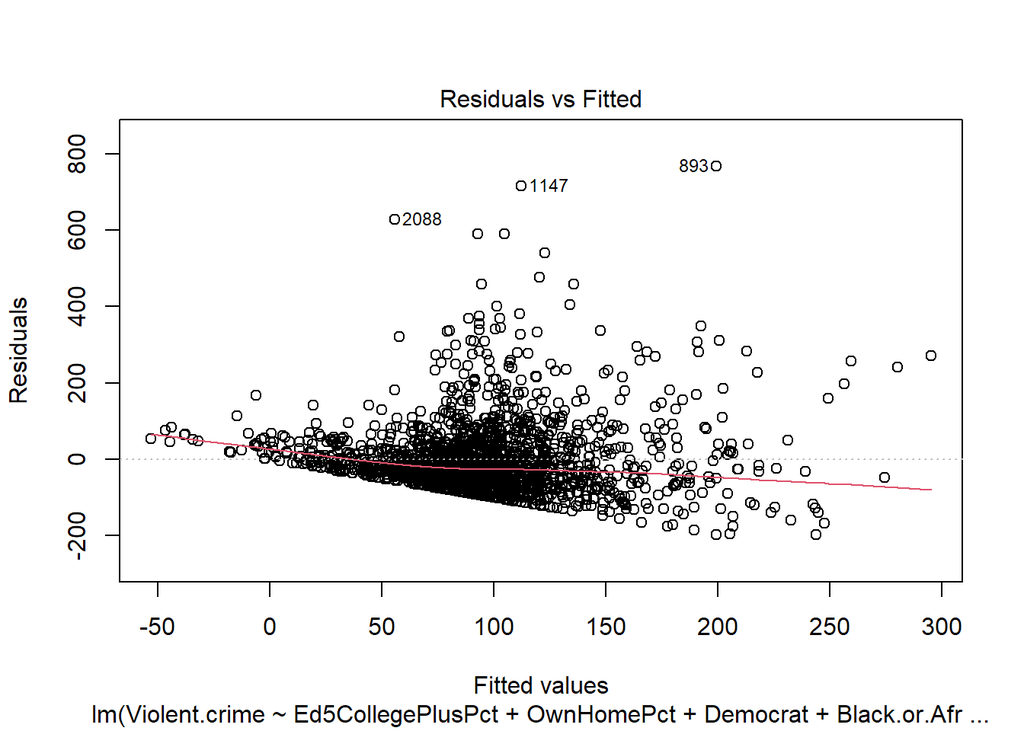

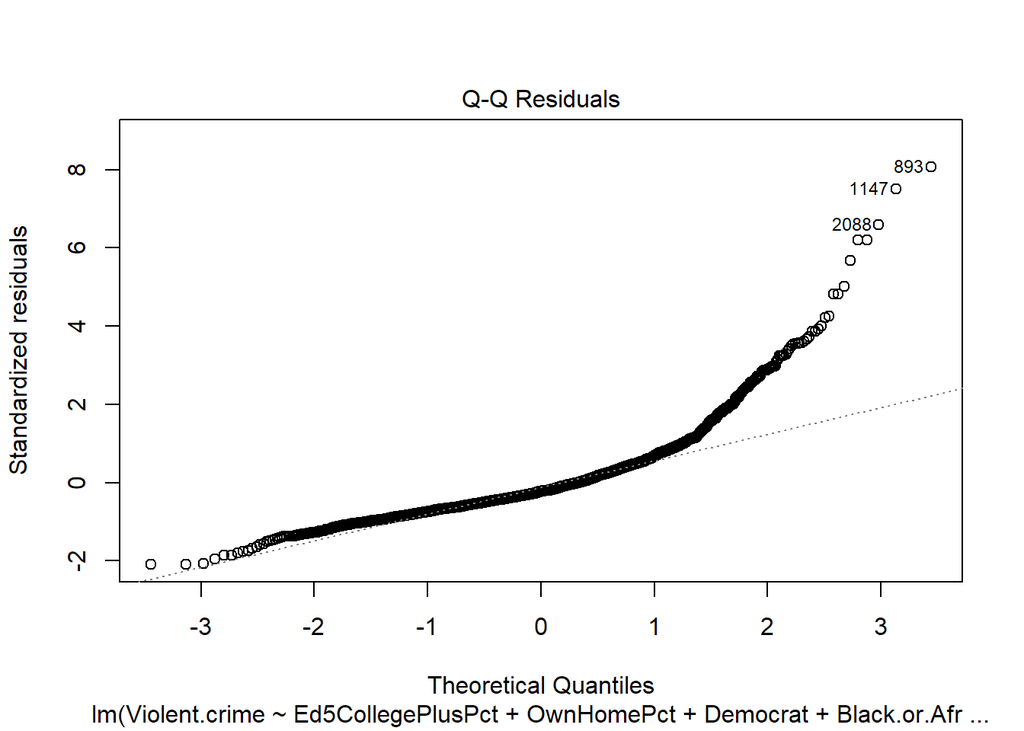

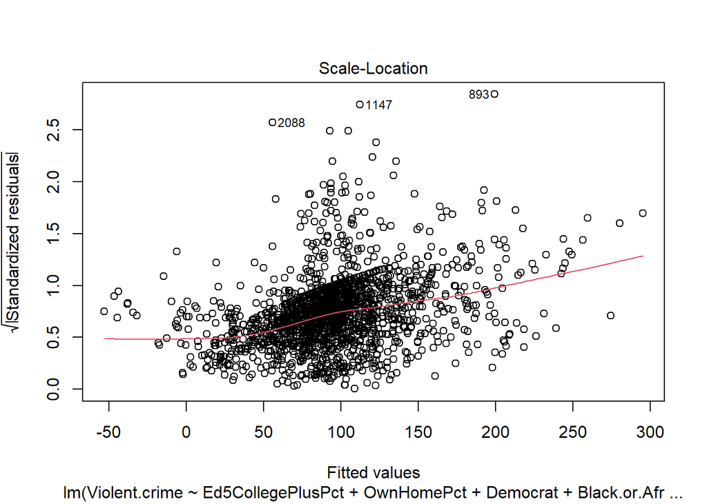

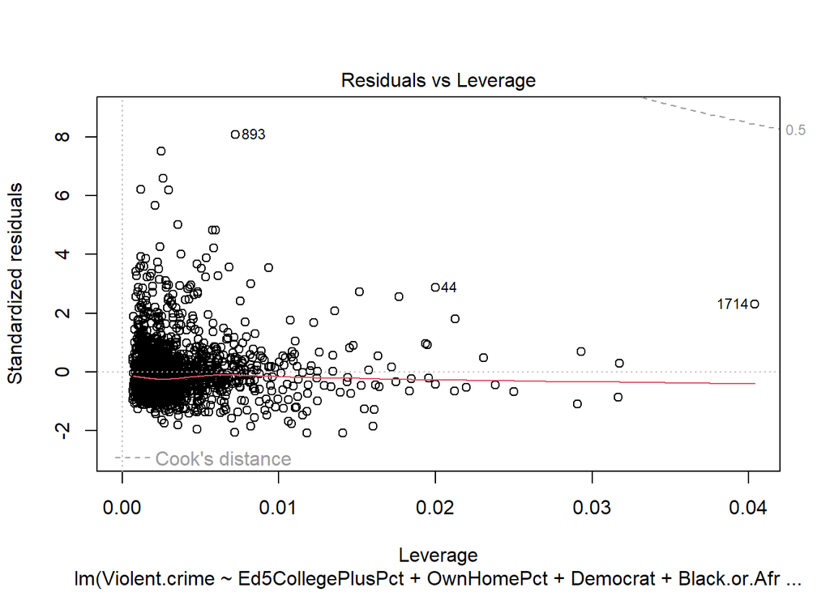

```r
plot(fit_lm_2_back5)
```

## 5.3 LASSO without political affiliation

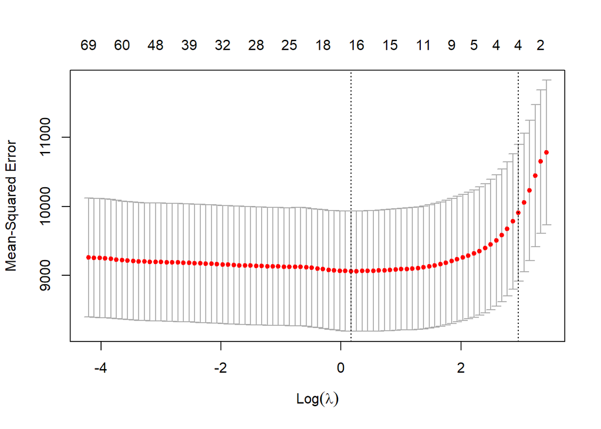

```r
set.seed(527)
x_lasso_no_gov <- model.matrix(Violent.crime~.-Democrat-Republican, data=crime)[, -1]
fit_lasso_3 <- cv.glmnet(x = x_lasso_no_gov,y=y_lasso,data=crime,alpha=1,nfolds = 10)
plot(fit_lasso_3)
```

```r
#fit_lasso_3$lambda.min=3.26

fit_lasso_model_3 <- glmnet(x = x_lasso_no_gov,y=y_lasso,data=crime,alpha=1,lambda=3.26)
sig_var_3 <- coef(fit_lasso_model_3)
as.data.frame(sig_var_3[which(sig_var_3 !=0),])
```

```
##                                                        sig_var_3[which(sig_var_3 != 0), ]
## (Intercept)                                                                  6.864513e+01
## AGE85PLUS_FEM                                                               -4.778023e-04
## PerCapitaInc                                                                -2.090600e-04
## PovertyAllAgesPct                                                            1.867027e-01
## Ed1LessThanHSPct                                                             6.188261e-01
## Ed5CollegePlusPct                                                           -3.905720e-01
## OwnHomePct                                                                   1.075485e+00
## NumUnemployed2019                                                           -3.491254e-04
## Tier_2                                                                      -7.376176e+00
## Tier_3                                                                      -1.657700e+01
## Black.or.African.American.alone..percent..2013                               1.837767e+00
## American.Indian.and.Alaska.Native.alone..percent..2013                       7.505482e-01
## Two.or.More.Races..percent..2013                                             1.850194e-01
```

```r
fit_lm_3 <- lm(Violent.crime~AGE85PLUS_FEM+Ed3SomeCollegePct+
                   Ed5CollegePlusPct+OwnHomePct+Tier_3+Tier_4+
                   Black.or.African.American.alone..percent..2013+
                   Native.Hawaiian.and.Other.Pacific.Islander.alone..percent.+
                   Two.or.More.Races..percent..2013
                   ,data=crime)
summary(fit_lm_3)
```

```
##
## Call:
## lm(formula = Violent.crime ~ AGE85PLUS_FEM + Ed3SomeCollegePct +
##     Ed5CollegePlusPct + OwnHomePct + Tier_3 + Tier_4 + Black.or.African.American.alone..percent..2013 +
##     Native.Hawaiian.and.Other.Pacific.Islander.alone..percent. +
##     Two.or.More.Races..percent..2013, data = crime)
##
## Residuals:
##     Min      1Q  Median      3Q     Max
## -209.52  -55.91  -19.10   27.71  758.73
##
## Coefficients:
##                                                              Estimate
## (Intercept)                                                 38.717451
## AGE85PLUS_FEM                                               -0.002187
## Ed3SomeCollegePct                                            0.141856
## Ed5CollegePlusPct                                           -1.170911
## OwnHomePct                                                   1.479986
## Tier_3                                                     -23.733694
## Tier_4                                                       2.014254
## Black.or.African.American.alone..percent..2013               2.322096
## Native.Hawaiian.and.Other.Pacific.Islander.alone..percent. -13.783948
## Two.or.More.Races..percent..2013                             6.936310
##                                                            Std. Error t value
## (Intercept)                                                 32.978856   1.174
## AGE85PLUS_FEM                                                0.001033  -2.116
## Ed3SomeCollegePct                                            0.649907   0.218
## Ed5CollegePlusPct                                            0.348303  -3.362
## OwnHomePct                                                   0.362769   4.080
## Tier_3                                                       4.194686  -5.658
## Tier_4                                                       4.461606   0.451
## Black.or.African.American.alone..percent..2013               0.189901  12.228
## Native.Hawaiian.and.Other.Pacific.Islander.alone..percent.  17.795482  -0.775
## Two.or.More.Races..percent..2013                             2.282607   3.039
##                                                            Pr(>|t|)
## (Intercept)                                                0.240553
## AGE85PLUS_FEM                                              0.034493 *
## Ed3SomeCollegePct                                          0.827243
## Ed5CollegePlusPct                                          0.000791 ***
## OwnHomePct                                                 4.71e-05 ***
## Tier_3                                                     1.79e-08 ***
## Tier_4                                                     0.651712
## Black.or.African.American.alone..percent..2013              < 2e-16 ***
## Native.Hawaiian.and.Other.Pacific.Islander.alone..percent. 0.438696
## Two.or.More.Races..percent..2013                           0.002411 **
## ---
## Signif. codes:  0 '***' 0.001 '**' 0.01 '*' 0.05 '.' 0.1 ' ' 1
##
## Residual standard error: 94.71 on 1728 degrees of freedom
## Multiple R-squared:  0.1735, Adjusted R-squared:  0.1692
## F-statistic: 40.32 on 9 and 1728 DF,  p-value: < 2.2e-16
```

```r
fit_lm_3_back1 <- lm(Violent.crime~Ed3SomeCollegePct+
                   Ed5CollegePlusPct+OwnHomePct+Tier_3+Tier_4+
                   Black.or.African.American.alone..percent..2013+
                   Native.Hawaiian.and.Other.Pacific.Islander.alone..percent.+
                   Two.or.More.Races..percent..2013
                   ,data=crime)
summary(fit_lm_3_back1)
```

```
##
## Call:
## lm(formula = Violent.crime ~ Ed3SomeCollegePct + Ed5CollegePlusPct +
##     OwnHomePct + Tier_3 + Tier_4 + Black.or.African.American.alone..percent..2013 +
##     Native.Hawaiian.and.Other.Pacific.Islander.alone..percent. +
##     Two.or.More.Races..percent..2013, data = crime)
##
## Residuals:
##     Min      1Q  Median      3Q     Max
## -209.21  -56.33  -19.31   27.68  760.85
##
## Coefficients:
##                                                            Estimate Std. Error
## (Intercept)                                                 36.7954    32.9995
## Ed3SomeCollegePct                                            0.2243     0.6494
## Ed5CollegePlusPct                                           -1.2780     0.3450
## OwnHomePct                                                   1.5466     0.3618
## Tier_3                                                     -24.1553     4.1942
## Tier_4                                                       0.4717     4.4061
## Black.or.African.American.alone..percent..2013               2.2862     0.1893
## Native.Hawaiian.and.Other.Pacific.Islander.alone..percent. -14.5001    17.8101
## Two.or.More.Races..percent..2013                             6.6665     2.2813
##                                                            t value Pr(>|t|)
## (Intercept)                                                  1.115 0.264993
## Ed3SomeCollegePct                                            0.345 0.729857
## Ed5CollegePlusPct                                           -3.705 0.000218 ***
## OwnHomePct                                                   4.275 2.01e-05 ***
## Tier_3                                                      -5.759 9.98e-09 ***
## Tier_4                                                       0.107 0.914758
## Black.or.African.American.alone..percent..2013              12.075  < 2e-16 ***
## Native.Hawaiian.and.Other.Pacific.Islander.alone..percent.  -0.814 0.415672
## Two.or.More.Races..percent..2013                             2.922 0.003521 **
## ---
## Signif. codes:  0 '***' 0.001 '**' 0.01 '*' 0.05 '.' 0.1 ' ' 1
##
## Residual standard error: 94.8 on 1729 degrees of freedom
## Multiple R-squared:  0.1714, Adjusted R-squared:  0.1676
## F-statistic: 44.71 on 8 and 1729 DF,  p-value: < 2.2e-16
```

```r
fit_lm_3_back2 <- lm(Violent.crime~Ed3SomeCollegePct+
                   Ed5CollegePlusPct+OwnHomePct+Tier_4+
                   Black.or.African.American.alone..percent..2013+
                   Native.Hawaiian.and.Other.Pacific.Islander.alone..percent.+
                   Two.or.More.Races..percent..2013
                   ,data=crime)
summary(fit_lm_3_back2)
```

```
##
## Call:
## lm(formula = Violent.crime ~ Ed3SomeCollegePct + Ed5CollegePlusPct +
##     OwnHomePct + Tier_4 + Black.or.African.American.alone..percent..2013 +
##     Native.Hawaiian.and.Other.Pacific.Islander.alone..percent. +
##     Two.or.More.Races..percent..2013, data = crime)
##
## Residuals:
##     Min      1Q  Median      3Q     Max
## -203.47  -57.50  -21.54   28.67  772.90
##
## Coefficients:
##                                                            Estimate Std. Error
## (Intercept)                                                 -0.8057    32.6465
## Ed3SomeCollegePct                                            0.2320     0.6554
## Ed5CollegePlusPct                                           -1.7319     0.3389
## OwnHomePct                                                   1.6808     0.3644
## Tier_4                                                     -14.4501     3.5968
## Black.or.African.American.alone..percent..2013               2.3579     0.1907
## Native.Hawaiian.and.Other.Pacific.Islander.alone..percent. -20.4603    17.9446
## Two.or.More.Races..percent..2013                             7.5197     2.2976
##                                                            t value Pr(>|t|)
## (Intercept)                                                 -0.025  0.98031
## Ed3SomeCollegePct                                            0.354  0.72343
## Ed5CollegePlusPct                                           -5.110 3.58e-07 ***
## OwnHomePct                                                   4.613 4.26e-06 ***
## Tier_4                                                      -4.018 6.13e-05 ***
## Black.or.African.American.alone..percent..2013              12.366  < 2e-16 ***
## Native.Hawaiian.and.Other.Pacific.Islander.alone..percent.  -1.140  0.25436
## Two.or.More.Races..percent..2013                             3.273  0.00109 **
## ---
## Signif. codes:  0 '***' 0.001 '**' 0.01 '*' 0.05 '.' 0.1 ' ' 1
##
## Residual standard error: 95.68 on 1730 degrees of freedom
## Multiple R-squared:  0.1555, Adjusted R-squared:  0.1521
## F-statistic: 45.51 on 7 and 1730 DF,  p-value: < 2.2e-16
```

```r
fit_lm_3_back3 <- lm(Violent.crime~Ed3SomeCollegePct+
                   Ed5CollegePlusPct+OwnHomePct+Tier_4+
                   Black.or.African.American.alone..percent..2013+
                   Two.or.More.Races..percent..2013
                   ,data=crime)
summary(fit_lm_3_back3)
```

```
##
## Call:
## lm(formula = Violent.crime ~ Ed3SomeCollegePct + Ed5CollegePlusPct +
##     OwnHomePct + Tier_4 + Black.or.African.American.alone..percent..2013 +
##     Two.or.More.Races..percent..2013, data = crime)
##
## Residuals:
##     Min      1Q  Median      3Q     Max
## -203.05  -57.32  -21.51   28.34  771.45
##
## Coefficients:
##                                                Estimate Std. Error t value
## (Intercept)                                     -5.6137    32.3759  -0.173
## Ed3SomeCollegePct                                0.1412     0.6506   0.217
## Ed5CollegePlusPct                               -1.7349     0.3390  -5.118
## OwnHomePct                                       1.7703     0.3558   4.975
## Tier_4                                         -14.7215     3.5892  -4.102
## Black.or.African.American.alone..percent..2013   2.3633     0.1906  12.397
## Two.or.More.Races..percent..2013                 7.0903     2.2667   3.128
##                                                Pr(>|t|)
## (Intercept)                                     0.86236
## Ed3SomeCollegePct                               0.82827
## Ed5CollegePlusPct                              3.43e-07 ***
## OwnHomePct                                     7.17e-07 ***
## Tier_4                                         4.29e-05 ***
## Black.or.African.American.alone..percent..2013  < 2e-16 ***
## Two.or.More.Races..percent..2013                0.00179 **
## ---
## Signif. codes:  0 '***' 0.001 '**' 0.01 '*' 0.05 '.' 0.1 ' ' 1
##
## Residual standard error: 95.69 on 1731 degrees of freedom
## Multiple R-squared:  0.1549, Adjusted R-squared:  0.1519
## F-statistic: 52.87 on 6 and 1731 DF,  p-value: < 2.2e-16
```

```r
fit_lm_3_back4 <- lm(Violent.crime~
                   Ed5CollegePlusPct+OwnHomePct+Tier_4+
                   Black.or.African.American.alone..percent..2013+
                   Two.or.More.Races..percent..2013
                   ,data=crime)
summary(fit_lm_3_back4)
```

```
##
## Call:
## lm(formula = Violent.crime ~ Ed5CollegePlusPct + OwnHomePct +
##     Tier_4 + Black.or.African.American.alone..percent..2013 +
##     Two.or.More.Races..percent..2013, data = crime)
##
## Residuals:
##     Min      1Q  Median      3Q     Max
## -202.79  -57.38  -21.24   28.64  771.46
##
## Coefficients:
##                                                Estimate Std. Error t value
## (Intercept)                                     -2.6616    29.3695  -0.091
## Ed5CollegePlusPct                               -1.7328     0.3387  -5.116
## OwnHomePct                                       1.7714     0.3557   4.980
## Tier_4                                         -14.7901     3.5742  -4.138
## Black.or.African.American.alone..percent..2013   2.3572     0.1885  12.505
## Two.or.More.Races..percent..2013                 7.1983     2.2108   3.256
##                                                Pr(>|t|)
## (Intercept)                                     0.92780
## Ed5CollegePlusPct                              3.47e-07 ***
## OwnHomePct                                     6.99e-07 ***
## Tier_4                                         3.67e-05 ***
## Black.or.African.American.alone..percent..2013  < 2e-16 ***
## Two.or.More.Races..percent..2013                0.00115 **
## ---
## Signif. codes:  0 '***' 0.001 '**' 0.01 '*' 0.05 '.' 0.1 ' ' 1
##
## Residual standard error: 95.66 on 1732 degrees of freedom
## Multiple R-squared:  0.1549, Adjusted R-squared:  0.1524
## F-statistic: 63.47 on 5 and 1732 DF,  p-value: < 2.2e-16
```

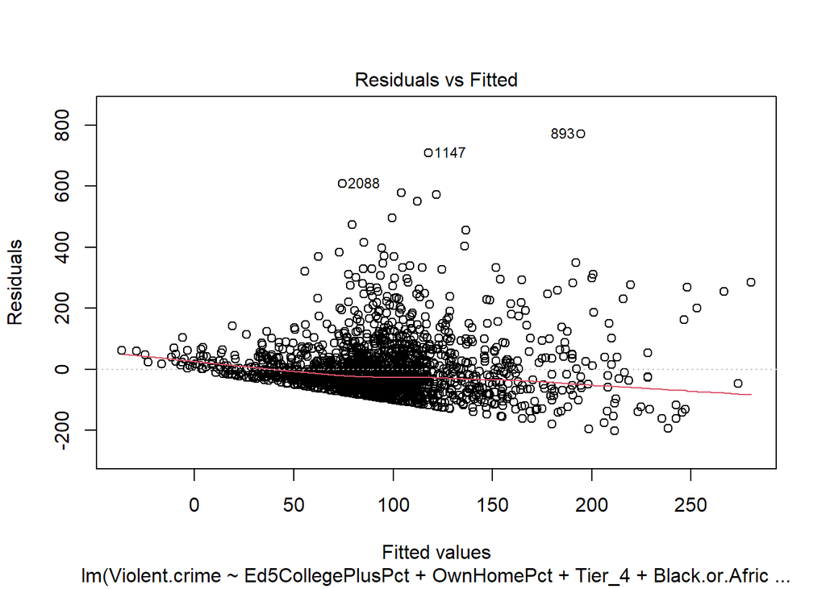

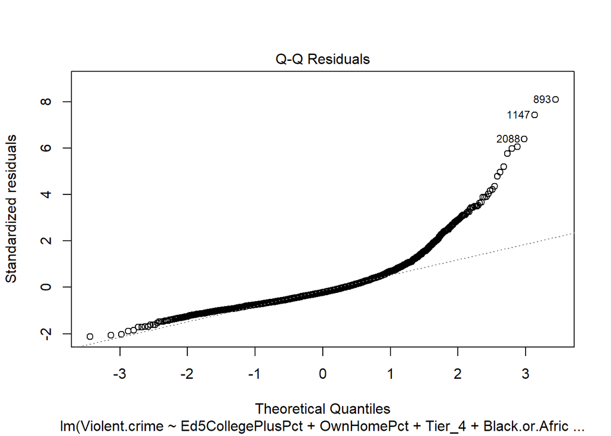

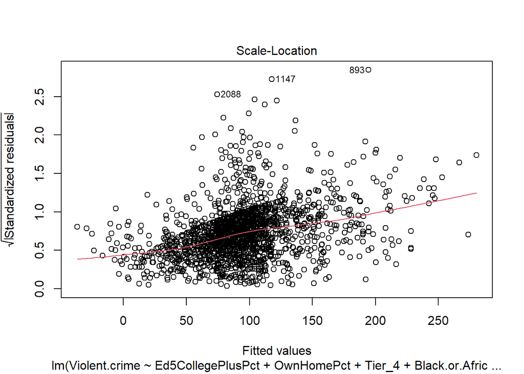

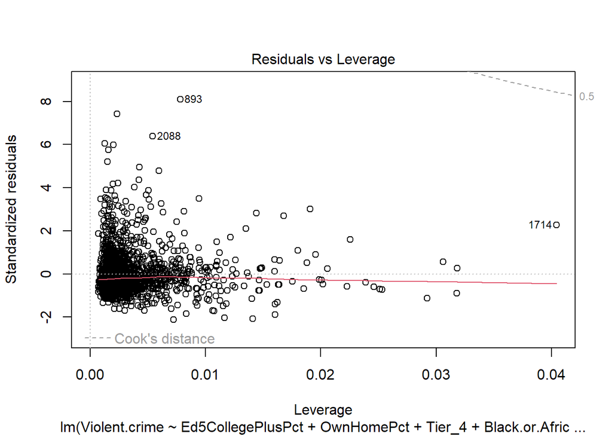

```r
plot(fit_lm_3_back4)
```

# 6 Testing Models

```r
Error1 <- sum((test$Violent.crime-predict(fit_lm_back7,newdata=test))^2)
Error2 <- sum((test$Violent.crime-predict(fit_lm_2_back5,newdata=test))^2)
Error3 <- sum((test$Violent.crime-predict(fit_lm_3_back4,newdata=test))^2)
Error1
```

```
## [1] 7809029
```

```r
Error2
```

```
## [1] 7860475
```

```r
Error3
```

```
## [1] 7789900
```

The final model will be the LASSO without political affiliation with the least RSS.

# 7 Result

From the final LASSO model, we identify the significant variables influencing violent crime rate includes the following: people with college plus degree, percentage of people owning house, proportion of high speed Internet access, Black or African Americans population and mixed race population.

Factors that have positive coefficients, or appears to have positive correlation with violent crime rate holding other factors the same, includes percentage of people owning house, black/African American and mixed race population rate.

Factors that have negative coefficients, meaning on average crime rate decreases as the variable increases holding other factors constant, include percentage of people with college plus degree and high speed Internet access.

```r
coef(fit_lm_3_back4)
```

```
##                                    (Intercept)
##                                      -2.661558
##                              Ed5CollegePlusPct
##                                      -1.732809
##                                     OwnHomePct
##                                       1.771390
##                                         Tier_4
##                                     -14.790123
## Black.or.African.American.alone..percent..2013
##                                       2.357249
##               Two.or.More.Races..percent..2013
##                                       7.198335
```

# 8 Remarks

Observing our final linear model, we recognize the significant variables and make the following remarks as to possible reasons why they contribute to violent crime rates.

1. Access to higher education has a strong negative correlation with violent crime – this can be easily understood in that higher education lowers violence, where discrimination is lowered and accepting others.
2. Internet access also has a strong negative correlation with violent crime – we suspect this may be caused from more time spent online and leading to less motivation to commit violent crimes. The negative coefficient for this variable might also challenges the idea that video games contribute to violent crimes, though more investigations are required.
3. Home ownership is also strongly correlated with an increase in violent crime – one possible explanation for this might be that more housing allows for domestic violence or hate crimes.
4. Race continues to have a significant correlation with violent crime – we suspect there may be greater socio-economic factors that lead to these issues such as unequal opportunities or historical impacts.